# Case Study 02 DDS

Antonio Debouse

11/20/2019

#Case Study 02 - Final Project

Youtube Video Presenation at: https://youtu.be/g9Bf-9vVnF4

CaseStudy 2 Github Repository website: https://github.com/adebouse/Case-Study-2.git

Github website: adebouse.github.io

Introduction:

As a representative of DDS Analytics, I will focus my analysis on identifying varaibles a company can focus on to improve employee development and increase retention rates. Analyzing the frequencies of categorical variables and the medians of continuous variables for specific job titles we hope to identify key predictors that identify employees who are likely to remain and those who will leave/be fired.

Summary:

We discovered that Overtime, Stock Option and Job Level had a strong correlation with predicting Attrition, and it was possible that those job position with turnover rates higher than the overall company could be due high levels of retirement.

```r
library(readr)
library(tidyverse)
library(GGally)
```

```r
library(corrplot)
library(DataExplorer)
library(e1071)
library(caret)
library(class)
library(GoodmanKruskal)
library(PerformanceAnalytics)
library(scales)
#Import CaseStudy2 dataset

CaseStudy2 <- read.csv("C:/Users/Antonio Debouse/Desktop/Doing Data Science/GitHub/Case-Study-2/CaseStudy2-data.csv")


#Check for missing data

sum(is.na(CaseStudy2))
```

```
## [1] 0
```

```r
##No missing data



#Inspect dataset variables

str(CaseStudy2)
```

```
## 'data.frame':    870 obs. of  36 variables:
##  $ ID                      : int  1 2 3 4 5 6 7 8 9 10 ...
##  $ Age                     : int  32 40 35 32 24 27 41 37 34 34 ...
##  $ Attrition               : Factor w/ 2 levels "No","Yes": 1 1 1 1 1 1 1 1 1 1 ...
##  $ BusinessTravel          : Factor w/ 3 levels "Non-Travel","Travel_Frequently",..: 3 3 2 3 2 2 3 3 3 2 ...
##  $ DailyRate               : int  117 1308 200 801 567 294 1283 309 1333 653 ...
##  $ Department              : Factor w/ 3 levels "Human Resources",..: 3 2 2 3 2 2 2 3 3 2 ...
##  $ DistanceFromHome        : int  13 14 18 1 2 10 5 10 10 10 ...
##  $ Education               : int  4 3 2 4 1 2 5 4 4 4 ...
##  $ EducationField          : Factor w/ 6 levels "Human Resources",..: 2 4 2 3 6 2 4 2 2 6 ...
##  $ EmployeeCount           : int  1 1 1 1 1 1 1 1 1 1 ...
##  $ EmployeeNumber          : int  859 1128 1412 2016 1646 733 1448 1105 1055 1597 ...
##  $ EnvironmentSatisfaction : int  2 3 3 3 1 4 2 4 3 4 ...
##  $ Gender                  : Factor w/ 2 levels "Female","Male": 2 2 2 1 1 2 2 1 1 2 ...
##  $ HourlyRate              : int  73 44 60 48 32 32 90 88 87 92 ...
```

[output cut: 22 more lines]

```r
head(CaseStudy2)
```

```
##   ID Age Attrition    BusinessTravel DailyRate             Department
## 1  1  32        No     Travel_Rarely       117                  Sales
## 2  2  40        No     Travel_Rarely      1308 Research & Development
## 3  3  35        No Travel_Frequently       200 Research & Development
## 4  4  32        No     Travel_Rarely       801                  Sales
## 5  5  24        No Travel_Frequently       567 Research & Development
## 6  6  27        No Travel_Frequently       294 Research & Development
##   DistanceFromHome Education   EducationField EmployeeCount EmployeeNumber
## 1               13         4    Life Sciences             1            859
## 2               14         3          Medical             1           1128
## 3               18         2    Life Sciences             1           1412
## 4                1         4        Marketing             1           2016
## 5                2         1 Technical Degree             1           1646
## 6               10         2    Life Sciences             1            733
##   EnvironmentSatisfaction Gender HourlyRate JobInvolvement JobLevel
```

[output cut: 48 more lines]

```r
#Change varibles to factors

names <- c('Education','EnvironmentSatisfaction','JobInvolvement','JobLevel', 'JobSatisfaction','PerformanceRating','RelationshipSatisfaction','StockOptionLevel','WorkLifeBalance')


#Change character variables to factors
CaseStudy2[,names] <- lapply(CaseStudy2[,names] , factor)

str(CaseStudy2)
```

```
## 'data.frame':    870 obs. of  36 variables:
##  $ ID                      : int  1 2 3 4 5 6 7 8 9 10 ...
##  $ Age                     : int  32 40 35 32 24 27 41 37 34 34 ...
##  $ Attrition               : Factor w/ 2 levels "No","Yes": 1 1 1 1 1 1 1 1 1 1 ...
##  $ BusinessTravel          : Factor w/ 3 levels "Non-Travel","Travel_Frequently",..: 3 3 2 3 2 2 3 3 3 2 ...
##  $ DailyRate               : int  117 1308 200 801 567 294 1283 309 1333 653 ...
##  $ Department              : Factor w/ 3 levels "Human Resources",..: 3 2 2 3 2 2 2 3 3 2 ...
##  $ DistanceFromHome        : int  13 14 18 1 2 10 5 10 10 10 ...
##  $ Education               : Factor w/ 5 levels "1","2","3","4",..: 4 3 2 4 1 2 5 4 4 4 ...
##  $ EducationField          : Factor w/ 6 levels "Human Resources",..: 2 4 2 3 6 2 4 2 2 6 ...
##  $ EmployeeCount           : int  1 1 1 1 1 1 1 1 1 1 ...
##  $ EmployeeNumber          : int  859 1128 1412 2016 1646 733 1448 1105 1055 1597 ...
##  $ EnvironmentSatisfaction : Factor w/ 4 levels "1","2","3","4": 2 3 3 3 1 4 2 4 3 4 ...
##  $ Gender                  : Factor w/ 2 levels "Female","Male": 2 2 2 1 1 2 2 1 1 2 ...
##  $ HourlyRate              : int  73 44 60 48 32 32 90 88 87 92 ...
```

[output cut: 22 more lines]

```r
#Reorder columns with factors and integers grouped together, eliminate unneeded columns

CaseStudy2_reorg <- CaseStudy2[,c(4,6,8,9,12,13,15:19,24,26,27,29,32,2,5,7,14,20,21,22,25,30,31,33:36,3)]

view(CaseStudy2_reorg)

str(CaseStudy2_reorg)
```

```
## 'data.frame':    870 obs. of  31 variables:
##  $ BusinessTravel          : Factor w/ 3 levels "Non-Travel","Travel_Frequently",..: 3 3 2 3 2 2 3 3 3 2 ...
##  $ Department              : Factor w/ 3 levels "Human Resources",..: 3 2 2 3 2 2 2 3 3 2 ...
##  $ Education               : Factor w/ 5 levels "1","2","3","4",..: 4 3 2 4 1 2 5 4 4 4 ...
##  $ EducationField          : Factor w/ 6 levels "Human Resources",..: 2 4 2 3 6 2 4 2 2 6 ...
##  $ EnvironmentSatisfaction : Factor w/ 4 levels "1","2","3","4": 2 3 3 3 1 4 2 4 3 4 ...
##  $ Gender                  : Factor w/ 2 levels "Female","Male": 2 2 2 1 1 2 2 1 1 2 ...
##  $ JobInvolvement          : Factor w/ 4 levels "1","2","3","4": 3 2 3 3 3 3 4 2 3 2 ...
##  $ JobLevel                : Factor w/ 5 levels "1","2","3","4",..: 2 5 3 3 1 3 1 2 1 2 ...
##  $ JobRole                 : Factor w/ 9 levels "Healthcare Representative",..: 8 6 5 8 7 5 7 8 9 1 ...
##  $ JobSatisfaction         : Factor w/ 4 levels "1","2","3","4": 4 3 4 4 4 1 3 4 3 3 ...
##  $ MaritalStatus           : Factor w/ 3 levels "Divorced","Married",..: 1 3 3 2 3 1 2 1 2 2 ...
##  $ OverTime                : Factor w/ 2 levels "No","Yes": 1 1 1 1 2 1 2 2 2 1 ...
##  $ PerformanceRating       : Factor w/ 2 levels "3","4": 1 1 1 1 1 2 1 1 1 1 ...
##  $ RelationshipSatisfaction: Factor w/ 4 levels "1","2","3","4": 3 1 3 3 3 3 1 3 4 2 ...
```

[output cut: 17 more lines]

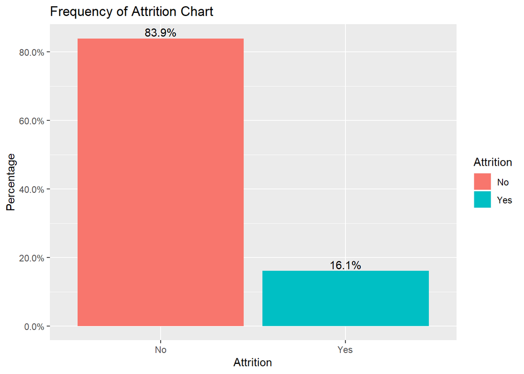

```r
#plot Overall Attrition frequency


CaseStudy2_reorg %>% ggplot(aes(x=Attrition, fill =Attrition))+
  geom_bar(aes(y = (..count..)/sum(..count..)))+
  geom_text(aes(y = ((..count..)/sum(..count..)), label = scales::percent((..count..)/sum(..count..))), stat = "count", vjust = -0.25) +
  scale_y_continuous(labels = percent) +
  ggtitle("Frequency of Attrition Chart")+
  ylab("Percentage")
```

```r
#Identify any trends specific to any job role

##Sum of Observations for each Job Role
print(CaseStudy2_reorg %>%
  group_by(JobRole) %>%
  summarize(count= n()) %>%
  arrange(desc(count)))
```

```
## # A tibble: 9 x 2
##   JobRole                   count
##   <fct>                     <int>
## 1 Sales Executive             200
## 2 Research Scientist          172
## 3 Laboratory Technician       153
## 4 Manufacturing Director       87
## 5 Healthcare Representative    76
## 6 Sales Representative         53
## 7 Manager                      51
## 8 Research Director            51
## 9 Human Resources              27
```

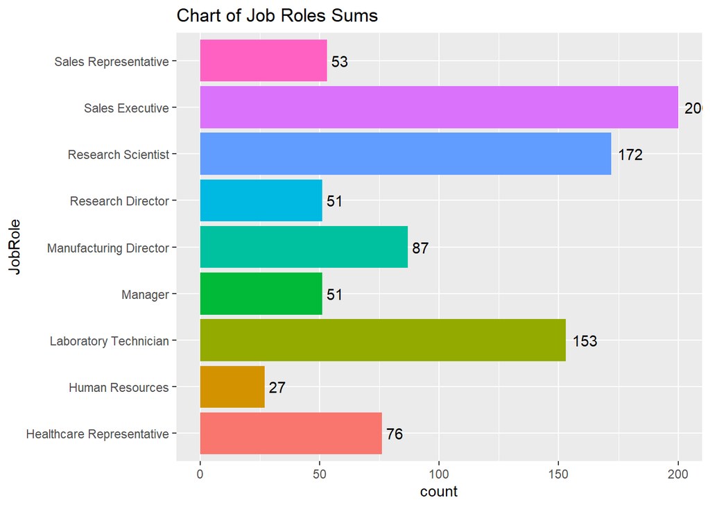

```r
##Barchart(count) for job roles

CaseStudy2_reorg %>% ggplot(aes(x= JobRole, fill = JobRole)) +
  geom_bar() +
  coord_flip()+
  geom_text(aes(label=..count..),stat = "count",hjust = -0.25)+
  ggtitle("Chart of Job Roles Sums")+
 theme(legend.position = "none")
```

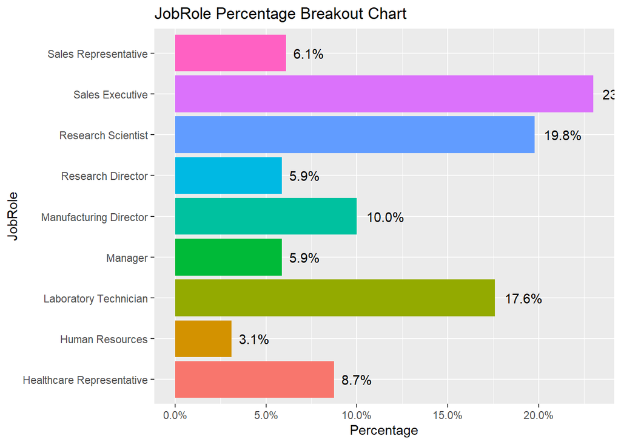

```r
##Barchart(percentage) for job roles

CaseStudy2_reorg %>% ggplot(aes(x=JobRole, fill =JobRole))+
  geom_bar(aes(y = (..count..)/sum(..count..)))+
  geom_text(aes(y = ((..count..)/sum(..count..)), label = scales::percent((..count..)/sum(..count..))), stat = "count", hjust = -0.25) +
  scale_y_continuous(labels = percent) +
  ggtitle("JobRole Percentage Breakout Chart")+
  ylab("Percentage")+
  theme(legend.position = "none")+
  coord_flip()
```

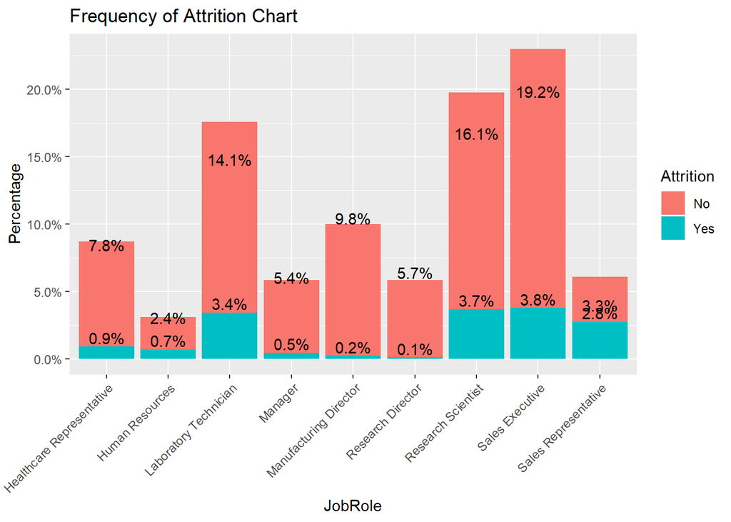

```r
##Create bar chart with Attrition percentages grouped by JobRole
CaseStudy2_reorg %>% ggplot(aes(x=JobRole, fill =Attrition))+
  geom_bar(aes(y = (..count..)/sum(..count..)))+
  geom_text(aes(y = ((..count..)/sum(..count..)), label = scales::percent((..count..)/sum(..count..)), vjust = -0.25), stat = "count") +
  scale_y_continuous(labels = percent) +
  ggtitle("Frequency of Attrition Chart")+
  ylab("Percentage")+
  theme(axis.text.x = element_text(angle = 45, hjust = 1))
```

```r
##Create Frequency table for Attrition grouped by JobRole
JobRoleAttrition_Frequency <- table(CaseStudy2_reorg$JobRole,CaseStudy2_reorg$Attrition)

##Feed JobRoleAttrition frequency table to prop.table() to produce relative percentages
JobRoleAttrition_Percentages <-round(prop.table(JobRoleAttrition_Frequency,margin = 1),2)

#Place table into dataframe
dataframecovert <- as.data.frame(JobRoleAttrition_Percentages)
dataframecovert$Freq <- dataframecovert$Freq * 100

#Change column names
colnames(dataframecovert) <- c("Job Title", "Attrition","Freq")


view(dataframecovert)

#Statistical Summary of Attrition = No, group by JobRole
dataframecovert %>% filter(Attrition == "No") %>%
  summary(dataframecovert$Freq)
```

```
##                      Job Title Attrition      Freq
##  Healthcare Representative:1   No :9     Min.   :55.00
##  Human Resources          :1   Yes:0     1st Qu.:80.00
##  Laboratory Technician    :1             Median :84.00
##  Manager                  :1             Mean   :83.89
##  Manufacturing Director   :1             3rd Qu.:92.00
##  Research Director        :1             Max.   :98.00
##  Research Scientist       :1
##  Sales Executive          :1
##  Sales Representative     :1
```

```r
#Standard deviation of Attrition = No, group by JobRole
dataframecovert %>% filter(Attrition == "No") %>%
  mutate(standev = sd(Freq))
```

```
##                   Job Title Attrition Freq  standev
## 1 Healthcare Representative        No   89 13.14767
## 2           Human Resources        No   78 13.14767
## 3     Laboratory Technician        No   80 13.14767
## 4                   Manager        No   92 13.14767
## 5    Manufacturing Director        No   98 13.14767
## 6         Research Director        No   98 13.14767
## 7        Research Scientist        No   81 13.14767
## 8           Sales Executive        No   84 13.14767
## 9      Sales Representative        No   55 13.14767
```

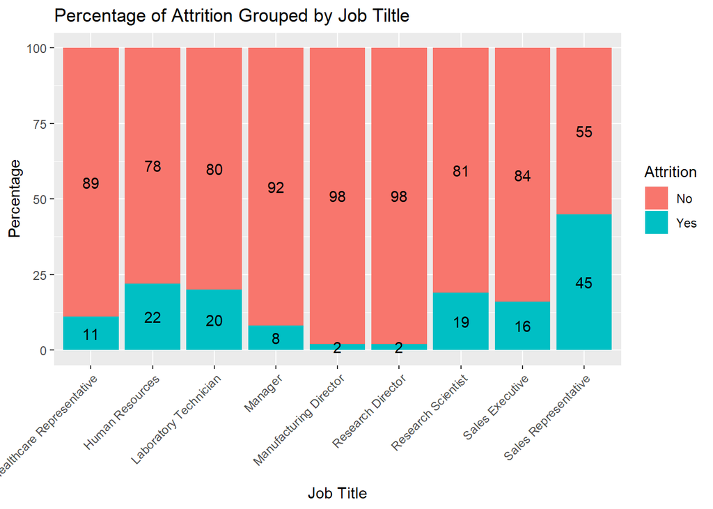

```r
#Create a column chart with relative percentage of Attrition grouped by JobRole

dataframecovert %>% ggplot(aes(x=`Job Title`, fill =Attrition,y=Freq))+
  geom_col()+
  geom_text(aes(label=Freq,),position = position_stack(vjust = 0.5))+
  theme(axis.text.x = element_text(angle = 45, hjust = 1))+
  ggtitle("Percentage of Attrition Grouped by Job Tiltle")+
  ylab("Percentage")
```

```r
###Create Frequency table for EducationField, Grouped by JobRole and sub-grouped by Attrition (yes/no)
###ftable(CaseStudy2_reorg$JobRole,CaseStudy2_reorg$Attrition,CaseStudy2_reorg$EducationField)
```

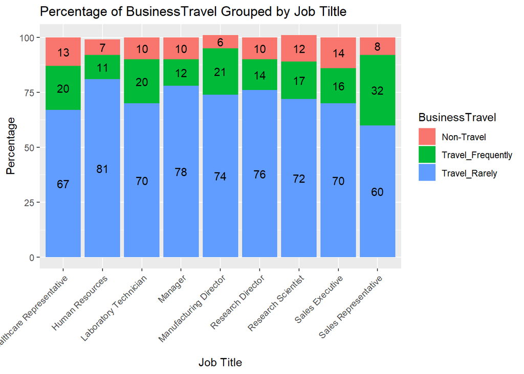

```r
##Create Frequency table for BusinessTravel grouped by JobRole
JobRole_BusinessTravel_Frequency <- table(CaseStudy2_reorg$JobRole,CaseStudy2_reorg$BusinessTravel)

##Feed JobRoleBusinessTravel frequency table to prop.table() to produce relative percentages
JobRole_BusinessTravel_Percentages <-round(prop.table(JobRole_BusinessTravel_Frequency,margin = 1),2)

#Place table into dataframe
dataframecovert <- as.data.frame(JobRole_BusinessTravel_Percentages)
dataframecovert$Freq <- dataframecovert$Freq * 100

#Change column names
colnames(dataframecovert) <- c("Job Title", "BusinessTravel","Freq")


view(dataframecovert)


#Create a column chart with relative percentage of BusinessTravel grouped by JobRole

dataframecovert %>% ggplot(aes(x=`Job Title`, fill =BusinessTravel,y=Freq))+
  geom_col()+
  geom_text(aes(label=Freq,),position = position_stack(vjust = 0.5))+
  theme(axis.text.x = element_text(angle = 45, hjust = 1))+
  ggtitle("Percentage of BusinessTravel Grouped by Job Tiltle")+
  ylab("Percentage")
```

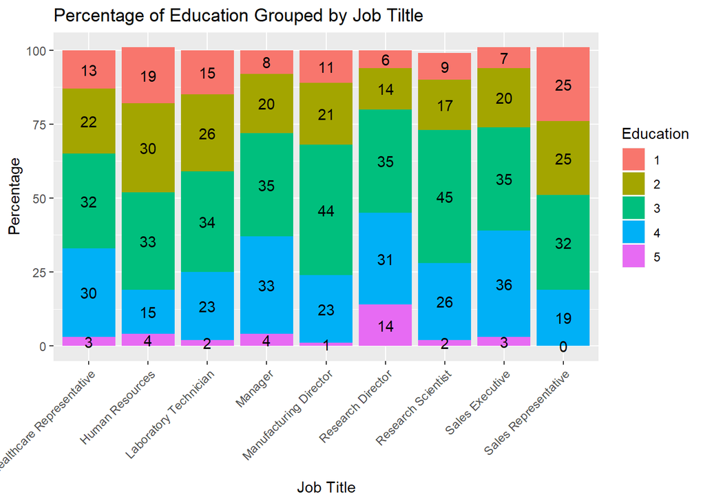

```r
##Create Frequency table for Education grouped by JobRole
JobRole_Education_Frequency <- table(CaseStudy2_reorg$JobRole,CaseStudy2_reorg$Education)

##Feed JobRole_Education frequency table to prop.table() to produce relative percentages
JobRole_Education_Percentages <-round(prop.table(JobRole_Education_Frequency,margin = 1),2)

#Place table into dataframe
dataframecovert <- as.data.frame(JobRole_Education_Percentages)
dataframecovert$Freq <- dataframecovert$Freq * 100

#Change column names
colnames(dataframecovert) <- c("Job Title", "Education","Freq")


view(dataframecovert)


#Create a column chart with relative percentage of Education grouped by JobRole

dataframecovert %>% ggplot(aes(x=`Job Title`, fill =Education,y=Freq))+
  geom_col()+
  geom_text(aes(label=Freq,),position = position_stack(vjust = 0.5))+
  theme(axis.text.x = element_text(angle = 45, hjust = 1))+
  ggtitle("Percentage of Education Grouped by Job Tiltle")+
  ylab("Percentage")
```

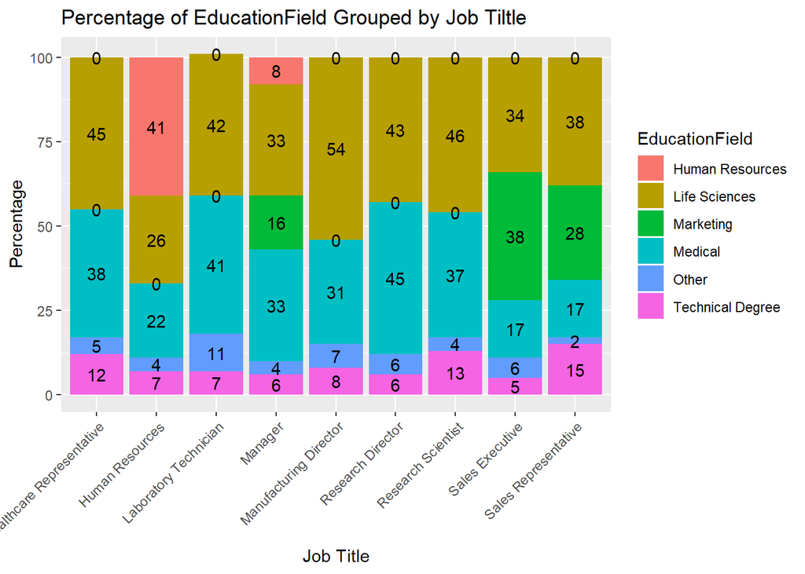

```r
##Create Frequency table for EducationField grouped by JobRole
JobRole_EducationField_Frequency <- table(CaseStudy2_reorg$JobRole,CaseStudy2_reorg$EducationField)

##Feed JobRole_EducationField frequency table to prop.table() to produce relative percentages
JobRole_EducationField_Percentages <-round(prop.table(JobRole_EducationField_Frequency,margin = 1),2)

#Place table into dataframe
dataframecovert <- as.data.frame(JobRole_EducationField_Percentages)
dataframecovert$Freq <- dataframecovert$Freq * 100

#Change column names
colnames(dataframecovert) <- c("Job Title", "EducationField","Freq")


#Create a column chart with relative percentage of EducationField grouped by JobRole

dataframecovert %>% ggplot(aes(x=`Job Title`, fill =EducationField,y=Freq))+
  geom_col()+
  geom_text(aes(label=Freq,),position = position_stack(vjust = 0.5))+
  theme(axis.text.x = element_text(angle = 45, hjust = 1))+
  ggtitle("Percentage of EducationField Grouped by Job Tiltle")+
  ylab("Percentage")
```

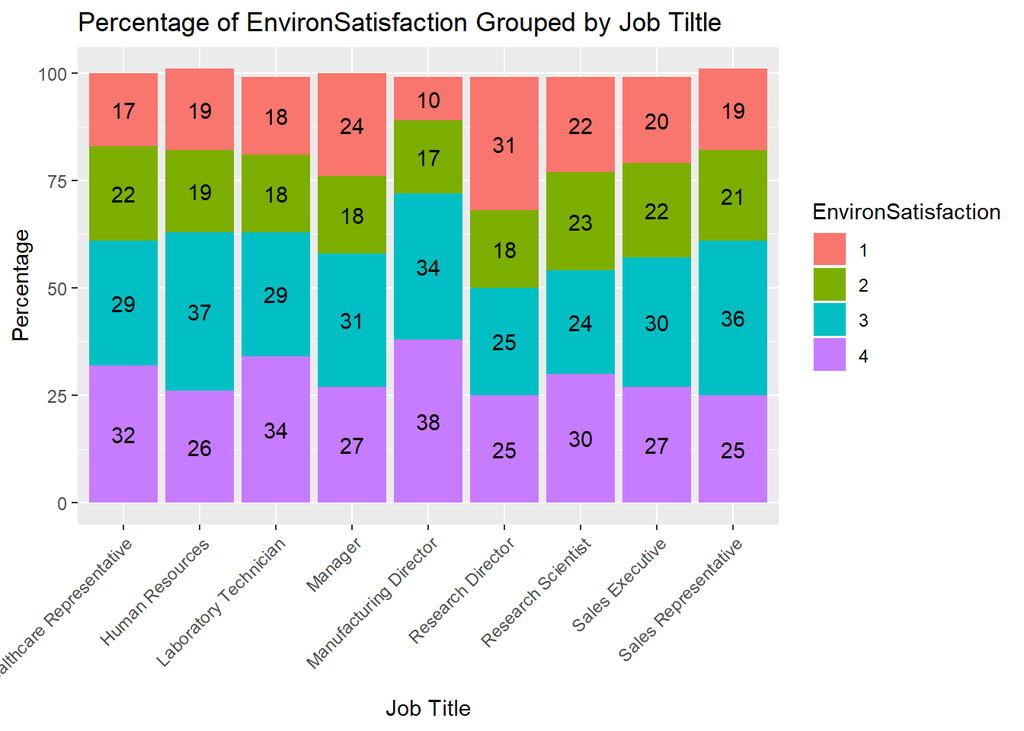

```r
##Create Frequency table for EnvironSatisfaction grouped by JobRole
JobRole_EnvironSatisfaction_Frequency <- table(CaseStudy2_reorg$JobRole,CaseStudy2_reorg$EnvironmentSatisfaction)

##Feed JobRole_EnvironSatisfaction frequency table to prop.table() to produce relative percentages
JobRole_EnvironSatisfaction_Percentages <-round(prop.table(JobRole_EnvironSatisfaction_Frequency,margin = 1),2)

#Place table into dataframe
dataframecovert <- as.data.frame(JobRole_EnvironSatisfaction_Percentages)
dataframecovert$Freq <- dataframecovert$Freq * 100

#Change column names
colnames(dataframecovert) <- c("Job Title", "EnvironSatisfaction","Freq")



#Create a column chart with relative percentage of EnvironSatisfaction grouped by JobRole

dataframecovert %>% ggplot(aes(x=`Job Title`, fill =EnvironSatisfaction,y=Freq))+
  geom_col()+
  geom_text(aes(label=Freq,),position = position_stack(vjust = 0.5))+
  theme(axis.text.x = element_text(angle = 45, hjust = 1))+
  ggtitle("Percentage of EnvironSatisfaction Grouped by Job Tiltle")+
  ylab("Percentage")
```

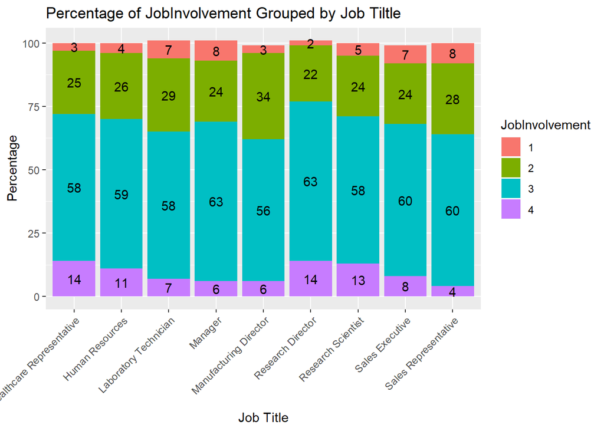

```r
##Create Frequency table for JobInvolvement grouped by JobRole
JobRole_JobInvolvement_Frequency <- table(CaseStudy2_reorg$JobRole,CaseStudy2_reorg$JobInvolvement)

##Feed JobRole_JobInvolvement frequency table to prop.table() to produce relative percentages
JobRole_JobInvolvement_Percentages <-round(prop.table(JobRole_JobInvolvement_Frequency,margin = 1),2)

#Place table into dataframe
dataframecovert <- as.data.frame(JobRole_JobInvolvement_Percentages)
dataframecovert$Freq <- dataframecovert$Freq * 100

#Change column names
colnames(dataframecovert) <- c("Job Title", "JobInvolvement","Freq")



#Create a column chart with relative percentage of JobInvolvement grouped by JobRole

dataframecovert %>% ggplot(aes(x=`Job Title`, fill =JobInvolvement,y=Freq))+
  geom_col()+
  geom_text(aes(label=Freq,),position = position_stack(vjust = 0.5))+
  theme(axis.text.x = element_text(angle = 45, hjust = 1))+
  ggtitle("Percentage of JobInvolvement Grouped by Job Tiltle")+
  ylab("Percentage")
```

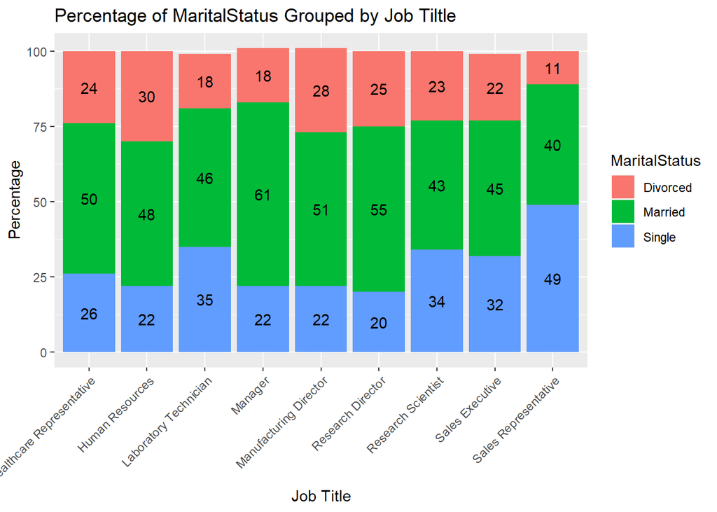

```r
##Create Frequency table for MaritalStatus grouped by JobRole
JobRole_MaritalStatus_Frequency <- table(CaseStudy2_reorg$JobRole,CaseStudy2_reorg$MaritalStatus)

##Feed JobRole_MaritalStatus frequency table to prop.table() to produce relative percentages
JobRole_MaritalStatus_Percentages <-round(prop.table(JobRole_MaritalStatus_Frequency,margin = 1),2)

#Place table into dataframe
dataframecovert <- as.data.frame(JobRole_MaritalStatus_Percentages)
dataframecovert$Freq <- dataframecovert$Freq * 100

#Change column names
colnames(dataframecovert) <- c("Job Title", "MaritalStatus","Freq")



#Create a column chart with relative percentage of MaritalStatus grouped by JobRole

dataframecovert %>% ggplot(aes(x=`Job Title`, fill =MaritalStatus,y=Freq))+
  geom_col()+
  geom_text(aes(label=Freq,),position = position_stack(vjust = 0.5))+
  theme(axis.text.x = element_text(angle = 45, hjust = 1))+
  ggtitle("Percentage of MaritalStatus Grouped by Job Tiltle")+
  ylab("Percentage")
```

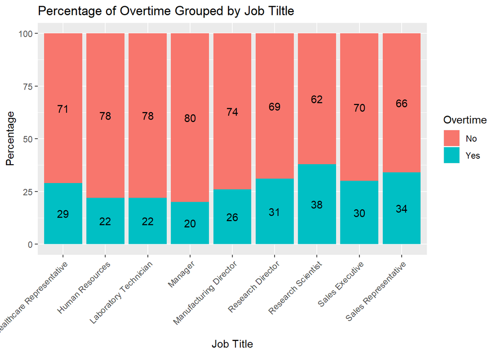

```r
##Create Frequency table for Overtime grouped by JobRole
JobRole_Overtime_Frequency <- table(CaseStudy2_reorg$JobRole,CaseStudy2_reorg$OverTime)

##Feed JobRole_Overtime frequency table to prop.table() to produce relative percentages
JobRole_Overtime_Percentages <-round(prop.table(JobRole_Overtime_Frequency,margin = 1),2)

#Place table into dataframe
dataframecovert <- as.data.frame(JobRole_Overtime_Percentages)
dataframecovert$Freq <- dataframecovert$Freq * 100

#Change column names
colnames(dataframecovert) <- c("Job Title", "Overtime","Freq")



#Create a column chart with relative percentage of Overtime grouped by JobRole

dataframecovert %>% ggplot(aes(x=`Job Title`, fill =Overtime,y=Freq))+
  geom_col()+
  geom_text(aes(label=Freq,),position = position_stack(vjust = 0.5))+
  theme(axis.text.x = element_text(angle = 45, hjust = 1))+
  ggtitle("Percentage of Overtime Grouped by Job Tiltle")+
  ylab("Percentage")
```

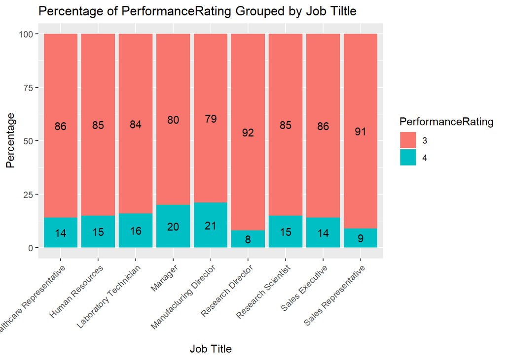

```r
##Create Frequency table for PerformanceRating grouped by JobRole
JobRole_PerformanceRating_Frequency <- table(CaseStudy2_reorg$JobRole,CaseStudy2_reorg$PerformanceRating)

##Feed JobRole_PerformanceRating frequency table to prop.table() to produce relative percentages
JobRole_PerformanceRating_Percentages <-round(prop.table(JobRole_PerformanceRating_Frequency,margin = 1),2)

#Place table into dataframe
dataframecovert <- as.data.frame(JobRole_PerformanceRating_Percentages)
dataframecovert$Freq <- dataframecovert$Freq * 100

#Change column names
colnames(dataframecovert) <- c("Job Title", "PerformanceRating","Freq")



#Create a column chart with relative percentage of PerformanceRating grouped by JobRole

dataframecovert %>% ggplot(aes(x=`Job Title`, fill =PerformanceRating,y=Freq))+
  geom_col()+
  geom_text(aes(label=Freq,),position = position_stack(vjust = 0.5))+
  theme(axis.text.x = element_text(angle = 45, hjust = 1))+
  ggtitle("Percentage of PerformanceRating Grouped by Job Tiltle")+
  ylab("Percentage")
```

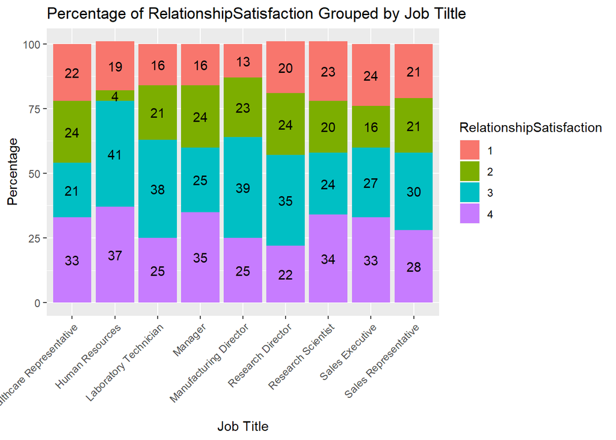

```r
##Create Frequency table for RelationshipSatisfaction grouped by JobRole
JobRole_RelationshipSatisfaction_Frequency <- table(CaseStudy2_reorg$JobRole,CaseStudy2_reorg$RelationshipSatisfaction
)

##Feed JobRole_RelationshipSatisfaction frequency table to prop.table() to produce relative percentages
JobRole_RelationshipSatisfaction_Percentages <-round(prop.table(JobRole_RelationshipSatisfaction_Frequency,margin = 1),2)

#Place table into dataframe
dataframecovert <- as.data.frame(JobRole_RelationshipSatisfaction_Percentages)
dataframecovert$Freq <- dataframecovert$Freq * 100

#Change column names
colnames(dataframecovert) <- c("Job Title", "RelationshipSatisfaction","Freq")



#Create a column chart with relative percentage of RelationshipSatisfaction grouped by JobRole

dataframecovert %>% ggplot(aes(x=`Job Title`, fill =RelationshipSatisfaction,y=Freq))+
  geom_col()+
  geom_text(aes(label=Freq,),position = position_stack(vjust = 0.5))+
  theme(axis.text.x = element_text(angle = 45, hjust = 1))+
  ggtitle("Percentage of RelationshipSatisfaction Grouped by Job Tiltle")+
  ylab("Percentage")
```

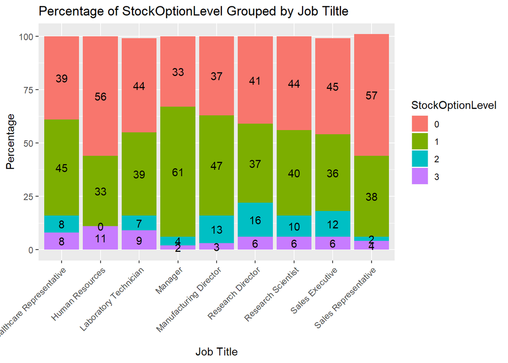

```r
##Create Frequency table for StockOptionLevel grouped by JobRole
JobRole_StockOptionLevel_Frequency <- table(CaseStudy2_reorg$JobRole,CaseStudy2_reorg$StockOptionLevel
)

##Feed JobRole_StockOptionLevel frequency table to prop.table() to produce relative percentages
JobRole_StockOptionLevel_Percentages <-round(prop.table(JobRole_StockOptionLevel_Frequency,margin = 1),2)

#Place table into dataframe
dataframecovert <- as.data.frame(JobRole_StockOptionLevel_Percentages)
dataframecovert$Freq <- dataframecovert$Freq * 100

#Change column names
colnames(dataframecovert) <- c("Job Title", "StockOptionLevel","Freq")



#Create a column chart with relative percentage of StockOptionLevel grouped by JobRole

dataframecovert %>% ggplot(aes(x=`Job Title`, fill =StockOptionLevel,y=Freq))+
  geom_col()+
  geom_text(aes(label=Freq,),position = position_stack(vjust = 0.5))+
  theme(axis.text.x = element_text(angle = 45, hjust = 1))+
  ggtitle("Percentage of StockOptionLevel Grouped by Job Tiltle")+
  ylab("Percentage")
```

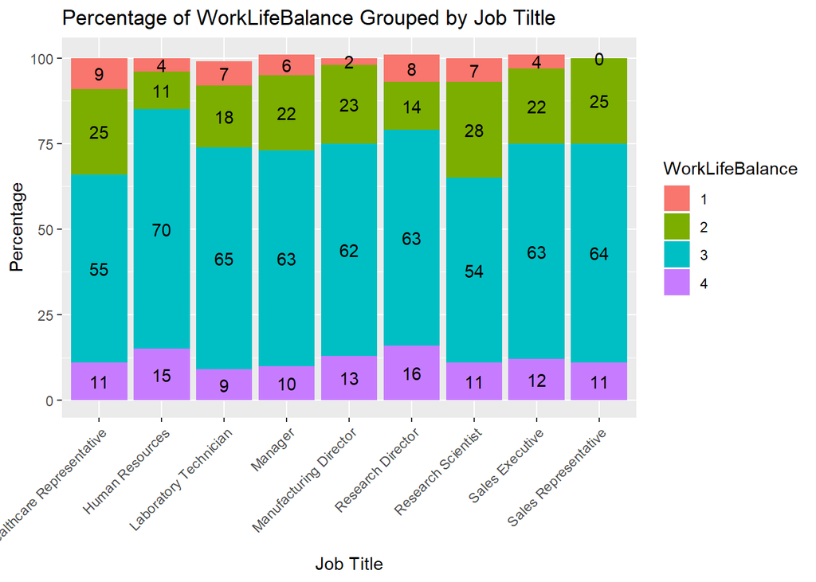

```r
##Create Frequency table for WorkLifeBalance grouped by JobRole
JobRole_WorkLifeBalance_Frequency <- table(CaseStudy2_reorg$JobRole,CaseStudy2_reorg$WorkLifeBalance
)

##Feed JobRole_WorkLifeBalance frequency table to prop.table() to produce relative percentages
JobRole_WorkLifeBalance_Percentages <-round(prop.table(JobRole_WorkLifeBalance_Frequency,margin = 1),2)

#Place table into dataframe
dataframecovert <- as.data.frame(JobRole_WorkLifeBalance_Percentages)
dataframecovert$Freq <- dataframecovert$Freq * 100

#Change column names
colnames(dataframecovert) <- c("Job Title", "WorkLifeBalance","Freq")



#Create a column chart with relative percentage of WorkLifeBalance grouped by JobRole

dataframecovert %>% ggplot(aes(x=`Job Title`, fill =WorkLifeBalance,y=Freq))+
  geom_col()+
  geom_text(aes(label=Freq,),position = position_stack(vjust = 0.5))+
  theme(axis.text.x = element_text(angle = 45, hjust = 1))+
  ggtitle("Percentage of WorkLifeBalance Grouped by Job Tiltle")+
  ylab("Percentage")
```

```r
##Statistical Summary of Continuous Variables grouped by JobRole
##medians of continuous variables grouped by JobRole

MediansofContinousVars <- CaseStudy2_reorg %>% group_by(JobRole) %>%
  summarise(Median_Age = median(Age),
            Median_DailyRate = median(DailyRate),
            Median_DistanceFromHome = median(DistanceFromHome),
            Median_HourlyRate = median(HourlyRate),
            Median_MonthlyIncome = median(MonthlyIncome),
            Median_MonthlyRate = median(MonthlyRate),
            Median_NumCompaniesWorked = median(NumCompaniesWorked),
            Median_PercentSalaryHike = median(PercentSalaryHike),
            Median_TotalWorkingYears = median(TotalWorkingYears),
            Median_TrainTimesLastYear = median(TrainingTimesLastYear),
            Median_YearsAtCompany = median(YearsAtCompany),
            Median_YearsINCurrentRole = median(YearsInCurrentRole),
            Median_YearsSinceLastPromotion = median(YearsSinceLastPromotion),
            Median_YearsWithCurrManager = median(YearsWithCurrManager))

summary(MediansofContinousVars)
```

```
##                       JobRole    Median_Age    Median_DailyRate
##  Healthcare Representative:1   Min.   :31.00   Min.   :688.0
##  Human Resources          :1   1st Qu.:34.00   1st Qu.:782.0
##  Laboratory Technician    :1   Median :35.00   Median :829.0
##  Manager                  :1   Mean   :36.89   Mean   :818.5
##  Manufacturing Director   :1   3rd Qu.:38.00   3rd Qu.:852.5
##  Research Director        :1   Max.   :47.00   Max.   :956.5
##  (Other)                  :3
##  Median_DistanceFromHome Median_HourlyRate Median_MonthlyIncome
##  Min.   :3.000           Min.   :58        Min.   : 2610
##  1st Qu.:7.000           1st Qu.:61        1st Qu.: 2774
##  Median :7.000           Median :66        Median : 6222
##  Mean   :6.778           Mean   :65        Mean   : 7096
##  3rd Qu.:8.000           3rd Qu.:69        3rd Qu.: 6796
##  Max.   :8.000           Max.   :70        Max.   :17174
##
##  Median_MonthlyRate Median_NumCompaniesWorked Median_PercentSalaryHike
##  Min.   :11585      Min.   :1.000             Min.   :14.00
##  1st Qu.:13137      1st Qu.:1.000             1st Qu.:14.00
##  Median :13556      Median :2.000             Median :14.00
##  Mean   :14047      Mean   :1.778             Mean   :14.22
##  3rd Qu.:14394      3rd Qu.:2.000             3rd Qu.:14.00
##  Max.   :16616      Max.   :3.000             Max.   :15.00
##
##  Median_TotalWorkingYears Median_TrainTimesLastYear Median_YearsAtCompany
##  Min.   : 3.00            Min.   :2.000             Min.   : 2.000
##  1st Qu.: 7.00            1st Qu.:3.000             1st Qu.: 4.000
##  Median :10.00            Median :3.000             Median : 7.000
##  Mean   :11.11            Mean   :2.889             Mean   : 6.389
##  3rd Qu.:11.00            3rd Qu.:3.000             3rd Qu.: 7.000
##  Max.   :24.00            Max.   :3.000             Max.   :13.000
##
##  Median_YearsINCurrentRole Median_YearsSinceLastPromotion
##  Min.   :2.000             Min.   :1.000
##  1st Qu.:2.000             1st Qu.:1.000
##  Median :4.000             Median :1.000
##  Mean   :4.111             Mean   :1.222
##  3rd Qu.:6.000             3rd Qu.:1.000
##  Max.   :7.000             Max.   :3.000
##
##  Median_YearsWithCurrManager
##  Min.   :2.000
##  1st Qu.:2.000
##  Median :4.000
##  Mean   :3.778
##  3rd Qu.:5.000
##  Max.   :7.000
##
```

```r
#Medians for Healthcare Rep
MediansofHCrepVars <- CaseStudy2_reorg %>% group_by(JobRole=="Healthcare Representative") %>%
  summarise(Median_Age = median(Age),
            Median_DailyRate = median(DailyRate),
            Median_DistanceFromHome = median(DistanceFromHome),
            Median_HourlyRate = median(HourlyRate),
            Median_MonthlyIncome = median(MonthlyIncome),
            Median_MonthlyRate = median(MonthlyRate),
            Median_NumCompaniesWorked = median(NumCompaniesWorked),
            Median_PercentSalaryHike = median(PercentSalaryHike),
            Median_TotalWorkingYears = median(TotalWorkingYears),
            Median_TrainTimesLastYear = median(TrainingTimesLastYear),
            Median_YearsAtCompany = median(YearsAtCompany),
            Median_YearsINCurrentRole = median(YearsInCurrentRole),
            Median_YearsSinceLastPromotion = median(YearsSinceLastPromotion),
            Median_YearsWithCurrManager = median(YearsWithCurrManager))
summary(MediansofHCrepVars)
```

```
##  JobRole == "Healthcare Representative"   Median_Age    Median_DailyRate
##  Mode :logical                          Min.   :35.00   Min.   :813.0
##  FALSE:1                                1st Qu.:35.75   1st Qu.:848.9
##  TRUE :1                                Median :36.50   Median :884.8
##                                         Mean   :36.50   Mean   :884.8
##                                         3rd Qu.:37.25   3rd Qu.:920.6
##                                         Max.   :38.00   Max.   :956.5
##  Median_DistanceFromHome Median_HourlyRate Median_MonthlyIncome
##  Min.   :7.00            Min.   :66.00     Min.   :4714
##  1st Qu.:7.25            1st Qu.:66.75     1st Qu.:5234
##  Median :7.50            Median :67.50     Median :5755
##  Mean   :7.50            Mean   :67.50     Mean   :5755
##  3rd Qu.:7.75            3rd Qu.:68.25     3rd Qu.:6276
##  Max.   :8.00            Max.   :69.00     Max.   :6796
##  Median_MonthlyRate Median_NumCompaniesWorked Median_PercentSalaryHike
##  Min.   :14022      Min.   :1.00              Min.   :14
##  1st Qu.:14095      1st Qu.:1.25              1st Qu.:14
##  Median :14167      Median :1.50              Median :14
##  Mean   :14167      Mean   :1.50              Mean   :14
##  3rd Qu.:14240      3rd Qu.:1.75              3rd Qu.:14
##  Max.   :14312      Max.   :2.00              Max.   :14
##  Median_TotalWorkingYears Median_TrainTimesLastYear Median_YearsAtCompany
##  Min.   : 9.0             Min.   :3                 Min.   :5.0
##  1st Qu.: 9.5             1st Qu.:3                 1st Qu.:5.5
##  Median :10.0             Median :3                 Median :6.0
##  Mean   :10.0             Mean   :3                 Mean   :6.0
##  3rd Qu.:10.5             3rd Qu.:3                 3rd Qu.:6.5
##  Max.   :11.0             Max.   :3                 Max.   :7.0
##  Median_YearsINCurrentRole Median_YearsSinceLastPromotion
##  Min.   :3.0               Min.   :1
##  1st Qu.:3.5               1st Qu.:1
##  Median :4.0               Median :1
##  Mean   :4.0               Mean   :1
##  3rd Qu.:4.5               3rd Qu.:1
##  Max.   :5.0               Max.   :1
##  Median_YearsWithCurrManager
##  Min.   :3.00
##  1st Qu.:3.25
##  Median :3.50
##  Mean   :3.50
##  3rd Qu.:3.75
##  Max.   :4.00
```

```r
#Medians for Human Resources
MediansofHR <- CaseStudy2_reorg %>% group_by(JobRole=="Human Resources") %>%
  summarise(Median_Age = median(Age),
            Median_DailyRate = median(DailyRate),
            Median_DistanceFromHome = median(DistanceFromHome),
            Median_HourlyRate = median(HourlyRate),
            Median_MonthlyIncome = median(MonthlyIncome),
            Median_MonthlyRate = median(MonthlyRate),
            Median_NumCompaniesWorked = median(NumCompaniesWorked),
            Median_PercentSalaryHike = median(PercentSalaryHike),
            Median_TotalWorkingYears = median(TotalWorkingYears),
            Median_TrainTimesLastYear = median(TrainingTimesLastYear),
            Median_YearsAtCompany = median(YearsAtCompany),
            Median_YearsINCurrentRole = median(YearsInCurrentRole),
            Median_YearsSinceLastPromotion = median(YearsSinceLastPromotion),
            Median_YearsWithCurrManager = median(YearsWithCurrManager))
summary(MediansofHR)
```

```
##  JobRole == "Human Resources"   Median_Age   Median_DailyRate
##  Mode :logical                Min.   :33.0   Min.   :817
##  FALSE:1                      1st Qu.:33.5   1st Qu.:820
##  TRUE :1                      Median :34.0   Median :823
##                               Mean   :34.0   Mean   :823
##                               3rd Qu.:34.5   3rd Qu.:826
##                               Max.   :35.0   Max.   :829
##  Median_DistanceFromHome Median_HourlyRate Median_MonthlyIncome
##  Min.   :7.00            Min.   :58        Min.   :2742
##  1st Qu.:7.25            1st Qu.:60        1st Qu.:3317
##  Median :7.50            Median :62        Median :3892
##  Mean   :7.50            Mean   :62        Mean   :3892
##  3rd Qu.:7.75            3rd Qu.:64        3rd Qu.:4467
##  Max.   :8.00            Max.   :66        Max.   :5042
##  Median_MonthlyRate Median_NumCompaniesWorked Median_PercentSalaryHike
##  Min.   :11585      Min.   :1.00              Min.   :14.00
##  1st Qu.:12208      1st Qu.:1.25              1st Qu.:14.25
##  Median :12830      Median :1.50              Median :14.50
##  Mean   :12830      Mean   :1.50              Mean   :14.50
##  3rd Qu.:13452      3rd Qu.:1.75              3rd Qu.:14.75
##  Max.   :14075      Max.   :2.00              Max.   :15.00
##  Median_TotalWorkingYears Median_TrainTimesLastYear Median_YearsAtCompany
##  Min.   : 6               Min.   :3                 Min.   :4.00
##  1st Qu.: 7               1st Qu.:3                 1st Qu.:4.25
##  Median : 8               Median :3                 Median :4.50
##  Mean   : 8               Mean   :3                 Mean   :4.50
##  3rd Qu.: 9               3rd Qu.:3                 3rd Qu.:4.75
##  Max.   :10               Max.   :3                 Max.   :5.00
##  Median_YearsINCurrentRole Median_YearsSinceLastPromotion
##  Min.   :2.00              Min.   :1
##  1st Qu.:2.25              1st Qu.:1
##  Median :2.50              Median :1
##  Mean   :2.50              Mean   :1
##  3rd Qu.:2.75              3rd Qu.:1
##  Max.   :3.00              Max.   :1
##  Median_YearsWithCurrManager
##  Min.   :2.00
##  1st Qu.:2.25
##  Median :2.50
##  Mean   :2.50
##  3rd Qu.:2.75
##  Max.   :3.00
```

```r
#Medians for Laboratory Technician
MediansofLabtech <- CaseStudy2_reorg %>% group_by(JobRole=="Laboratory Technician") %>%
  summarise(Median_Age = median(Age),
            Median_DailyRate = median(DailyRate),
            Median_DistanceFromHome = median(DistanceFromHome),
            Median_HourlyRate = median(HourlyRate),
            Median_MonthlyIncome = median(MonthlyIncome),
            Median_MonthlyRate = median(MonthlyRate),
            Median_NumCompaniesWorked = median(NumCompaniesWorked),
            Median_PercentSalaryHike = median(PercentSalaryHike),
            Median_TotalWorkingYears = median(TotalWorkingYears),
            Median_TrainTimesLastYear = median(TrainingTimesLastYear),
            Median_YearsAtCompany = median(YearsAtCompany),
            Median_YearsINCurrentRole = median(YearsInCurrentRole),
            Median_YearsSinceLastPromotion = median(YearsSinceLastPromotion),
            Median_YearsWithCurrManager = median(YearsWithCurrManager))
summary(MediansofLabtech)
```

```
##  JobRole == "Laboratory Technician"   Median_Age   Median_DailyRate
##  Mode :logical                      Min.   :34.0   Min.   :813.0
##  FALSE:1                            1st Qu.:34.5   1st Qu.:814.5
##  TRUE :1                            Median :35.0   Median :816.0
##                                     Mean   :35.0   Mean   :816.0
##                                     3rd Qu.:35.5   3rd Qu.:817.5
##                                     Max.   :36.0   Max.   :819.0
##  Median_DistanceFromHome Median_HourlyRate Median_MonthlyIncome
##  Min.   :7               Min.   :64.0      Min.   :2867
##  1st Qu.:7               1st Qu.:64.5      1st Qu.:3519
##  Median :7               Median :65.0      Median :4172
##  Mean   :7               Mean   :65.0      Mean   :4172
##  3rd Qu.:7               3rd Qu.:65.5      3rd Qu.:4824
##  Max.   :7               Max.   :66.0      Max.   :5476
##  Median_MonthlyRate Median_NumCompaniesWorked Median_PercentSalaryHike
##  Min.   :13556      Min.   :1.00              Min.   :14
##  1st Qu.:13728      1st Qu.:1.25              1st Qu.:14
##  Median :13899      Median :1.50              Median :14
##  Mean   :13899      Mean   :1.50              Mean   :14
##  3rd Qu.:14070      3rd Qu.:1.75              3rd Qu.:14
##  Max.   :14242      Max.   :2.00              Max.   :14
##  Median_TotalWorkingYears Median_TrainTimesLastYear Median_YearsAtCompany
##  Min.   : 8.0             Min.   :3                 Min.   :4.00
##  1st Qu.: 8.5             1st Qu.:3                 1st Qu.:4.25
##  Median : 9.0             Median :3                 Median :4.50
##  Mean   : 9.0             Mean   :3                 Mean   :4.50
##  3rd Qu.: 9.5             3rd Qu.:3                 3rd Qu.:4.75
##  Max.   :10.0             Max.   :3                 Max.   :5.00
##  Median_YearsINCurrentRole Median_YearsSinceLastPromotion
##  Min.   :2.00              Min.   :1
##  1st Qu.:2.25              1st Qu.:1
##  Median :2.50              Median :1
##  Mean   :2.50              Mean   :1
##  3rd Qu.:2.75              3rd Qu.:1
##  Max.   :3.00              Max.   :1
##  Median_YearsWithCurrManager
##  Min.   :2.00
##  1st Qu.:2.25
##  Median :2.50
##  Mean   :2.50
##  3rd Qu.:2.75
##  Max.   :3.00
```

```r
#Medians for Manager
MediansofManager <- CaseStudy2_reorg %>% group_by(JobRole== "Manager") %>%
  summarise(Median_Age = median(Age),
            Median_DailyRate = median(DailyRate),
            Median_DistanceFromHome = median(DistanceFromHome),
            Median_HourlyRate = median(HourlyRate),
            Median_MonthlyIncome = median(MonthlyIncome),
            Median_MonthlyRate = median(MonthlyRate),
            Median_NumCompaniesWorked = median(NumCompaniesWorked),
            Median_PercentSalaryHike = median(PercentSalaryHike),
            Median_TotalWorkingYears = median(TotalWorkingYears),
            Median_TrainTimesLastYear = median(TrainingTimesLastYear),
            Median_YearsAtCompany = median(YearsAtCompany),
            Median_YearsINCurrentRole = median(YearsInCurrentRole),
            Median_YearsSinceLastPromotion = median(YearsSinceLastPromotion),
            Median_YearsWithCurrManager = median(YearsWithCurrManager))
summary(MediansofManager)
```

```
##  JobRole == "Manager"   Median_Age Median_DailyRate
##  Mode :logical        Min.   :35   Min.   :688.0
##  FALSE:1              1st Qu.:38   1st Qu.:722.8
##  TRUE :1              Median :41   Median :757.5
##                       Mean   :41   Mean   :757.5
##                       3rd Qu.:44   3rd Qu.:792.2
##                       Max.   :47   Max.   :827.0
##  Median_DistanceFromHome Median_HourlyRate Median_MonthlyIncome
##  Min.   :3               Min.   :66        Min.   : 4735
##  1st Qu.:4               1st Qu.:67        1st Qu.: 7845
##  Median :5               Median :68        Median :10954
##  Mean   :5               Mean   :68        Mean   :10954
##  3rd Qu.:6               3rd Qu.:69        3rd Qu.:14064
##  Max.   :7               Max.   :70        Max.   :17174
##  Median_MonthlyRate Median_NumCompaniesWorked Median_PercentSalaryHike
##  Min.   :14034      Min.   :1.0               Min.   :14
##  1st Qu.:14680      1st Qu.:1.5               1st Qu.:14
##  Median :15325      Median :2.0               Median :14
##  Mean   :15325      Mean   :2.0               Mean   :14
##  3rd Qu.:15970      3rd Qu.:2.5               3rd Qu.:14
##  Max.   :16616      Max.   :3.0               Max.   :14
##  Median_TotalWorkingYears Median_TrainTimesLastYear Median_YearsAtCompany
##  Min.   : 9.00            Min.   :3                 Min.   : 5
##  1st Qu.:12.75            1st Qu.:3                 1st Qu.: 7
##  Median :16.50            Median :3                 Median : 9
##  Mean   :16.50            Mean   :3                 Mean   : 9
##  3rd Qu.:20.25            3rd Qu.:3                 3rd Qu.:11
##  Max.   :24.00            Max.   :3                 Max.   :13
##  Median_YearsINCurrentRole Median_YearsSinceLastPromotion
##  Min.   :3                 Min.   :1.0
##  1st Qu.:4                 1st Qu.:1.5
##  Median :5                 Median :2.0
##  Mean   :5                 Mean   :2.0
##  3rd Qu.:6                 3rd Qu.:2.5
##  Max.   :7                 Max.   :3.0
##  Median_YearsWithCurrManager
##  Min.   :3
##  1st Qu.:4
##  Median :5
##  Mean   :5
##  3rd Qu.:6
##  Max.   :7
```

```r
#Medians for Manufacturing Director
MediansofMD <- CaseStudy2_reorg %>% group_by(JobRole== "Manufacturing Director") %>%
  summarise(Median_Age = median(Age),
            Median_DailyRate = median(DailyRate),
            Median_DistanceFromHome = median(DistanceFromHome),
            Median_HourlyRate = median(HourlyRate),
            Median_MonthlyIncome = median(MonthlyIncome),
            Median_MonthlyRate = median(MonthlyRate),
            Median_NumCompaniesWorked = median(NumCompaniesWorked),
            Median_PercentSalaryHike = median(PercentSalaryHike),
            Median_TotalWorkingYears = median(TotalWorkingYears),
            Median_TrainTimesLastYear = median(TrainingTimesLastYear),
            Median_YearsAtCompany = median(YearsAtCompany),
            Median_YearsINCurrentRole = median(YearsInCurrentRole),
            Median_YearsSinceLastPromotion = median(YearsSinceLastPromotion),
            Median_YearsWithCurrManager = median(YearsWithCurrManager))
summary(MediansofMD)
```

```
##  JobRole == "Manufacturing Director"   Median_Age    Median_DailyRate
##  Mode :logical                       Min.   :35.00   Min.   :813.0
##  FALSE:1                             1st Qu.:35.25   1st Qu.:823.5
##  TRUE :1                             Median :35.50   Median :834.0
##                                      Mean   :35.50   Mean   :834.0
##                                      3rd Qu.:35.75   3rd Qu.:844.5
##                                      Max.   :36.00   Max.   :855.0
##  Median_DistanceFromHome Median_HourlyRate Median_MonthlyIncome
##  Min.   :7               Min.   :61.00     Min.   :4649
##  1st Qu.:7               1st Qu.:62.25     1st Qu.:5112
##  Median :7               Median :63.50     Median :5574
##  Mean   :7               Mean   :63.50     Mean   :5574
##  3rd Qu.:7               3rd Qu.:64.75     3rd Qu.:6036
##  Max.   :7               Max.   :66.00     Max.   :6499
##  Median_MonthlyRate Median_NumCompaniesWorked Median_PercentSalaryHike
##  Min.   :14004      Min.   :2                 Min.   :14.00
##  1st Qu.:14102      1st Qu.:2                 1st Qu.:14.25
##  Median :14199      Median :2                 Median :14.50
##  Mean   :14199      Mean   :2                 Mean   :14.50
##  3rd Qu.:14296      3rd Qu.:2                 3rd Qu.:14.75
##  Max.   :14394      Max.   :2                 Max.   :15.00
##  Median_TotalWorkingYears Median_TrainTimesLastYear Median_YearsAtCompany
##  Min.   : 9.00            Min.   :2.00              Min.   :5.0
##  1st Qu.: 9.25            1st Qu.:2.25              1st Qu.:5.5
##  Median : 9.50            Median :2.50              Median :6.0
##  Mean   : 9.50            Mean   :2.50              Mean   :6.0
##  3rd Qu.: 9.75            3rd Qu.:2.75              3rd Qu.:6.5
##  Max.   :10.00            Max.   :3.00              Max.   :7.0
##  Median_YearsINCurrentRole Median_YearsSinceLastPromotion
##  Min.   :3.00              Min.   :1
##  1st Qu.:3.75              1st Qu.:1
##  Median :4.50              Median :1
##  Mean   :4.50              Mean   :1
##  3rd Qu.:5.25              3rd Qu.:1
##  Max.   :6.00              Max.   :1
##  Median_YearsWithCurrManager
##  Min.   :3.0
##  1st Qu.:3.5
##  Median :4.0
##  Mean   :4.0
##  3rd Qu.:4.5
##  Max.   :5.0
```

```r
#Medians for Research Director
MediansofRD <- CaseStudy2_reorg %>% group_by(JobRole== "Research Director") %>%
  summarise(Median_Age = median(Age),
            Median_DailyRate = median(DailyRate),
            Median_DistanceFromHome = median(DistanceFromHome),
            Median_HourlyRate = median(HourlyRate),
            Median_MonthlyIncome = median(MonthlyIncome),
            Median_MonthlyRate = median(MonthlyRate),
            Median_NumCompaniesWorked = median(NumCompaniesWorked),
            Median_PercentSalaryHike = median(PercentSalaryHike),
            Median_TotalWorkingYears = median(TotalWorkingYears),
            Median_TrainTimesLastYear = median(TrainingTimesLastYear),
            Median_YearsAtCompany = median(YearsAtCompany),
            Median_YearsINCurrentRole = median(YearsInCurrentRole),
            Median_YearsSinceLastPromotion = median(YearsSinceLastPromotion),
            Median_YearsWithCurrManager = median(YearsWithCurrManager))
summary(MediansofRD)
```

```
##  JobRole == "Research Director"   Median_Age    Median_DailyRate
##  Mode :logical                  Min.   :35.00   Min.   :782.0
##  FALSE:1                        1st Qu.:37.25   1st Qu.:792.2
##  TRUE :1                        Median :39.50   Median :802.5
##                                 Mean   :39.50   Mean   :802.5
##                                 3rd Qu.:41.75   3rd Qu.:812.8
##                                 Max.   :44.00   Max.   :823.0
##  Median_DistanceFromHome Median_HourlyRate Median_MonthlyIncome
##  Min.   :7.00            Min.   :60.0      Min.   : 4735
##  1st Qu.:7.25            1st Qu.:61.5      1st Qu.: 7597
##  Median :7.50            Median :63.0      Median :10460
##  Mean   :7.50            Mean   :63.0      Mean   :10460
##  3rd Qu.:7.75            3rd Qu.:64.5      3rd Qu.:13322
##  Max.   :8.00            Max.   :66.0      Max.   :16184
##  Median_MonthlyRate Median_NumCompaniesWorked Median_PercentSalaryHike
##  Min.   :13934      Min.   :1.0               Min.   :14
##  1st Qu.:14524      1st Qu.:1.5               1st Qu.:14
##  Median :15113      Median :2.0               Median :14
##  Mean   :15113      Mean   :2.0               Mean   :14
##  3rd Qu.:15702      3rd Qu.:2.5               3rd Qu.:14
##  Max.   :16292      Max.   :3.0               Max.   :14
##  Median_TotalWorkingYears Median_TrainTimesLastYear Median_YearsAtCompany
##  Min.   : 9               Min.   :3                 Min.   :5
##  1st Qu.:12               1st Qu.:3                 1st Qu.:6
##  Median :15               Median :3                 Median :7
##  Mean   :15               Mean   :3                 Mean   :7
##  3rd Qu.:18               3rd Qu.:3                 3rd Qu.:8
##  Max.   :21               Max.   :3                 Max.   :9
##  Median_YearsINCurrentRole Median_YearsSinceLastPromotion
##  Min.   :3                 Min.   :1
##  1st Qu.:4                 1st Qu.:1
##  Median :5                 Median :1
##  Mean   :5                 Mean   :1
##  3rd Qu.:6                 3rd Qu.:1
##  Max.   :7                 Max.   :1
##  Median_YearsWithCurrManager
##  Min.   :3.00
##  1st Qu.:3.75
##  Median :4.50
##  Mean   :4.50
##  3rd Qu.:5.25
##  Max.   :6.00
```

```r
#Medians for Research Scientist
MediansofRS <- CaseStudy2_reorg %>% group_by(JobRole== "Research Scientist") %>%
  summarise(Median_Age = median(Age),
            Median_DailyRate = median(DailyRate),
            Median_DistanceFromHome = median(DistanceFromHome),
            Median_HourlyRate = median(HourlyRate),
            Median_MonthlyIncome = median(MonthlyIncome),
            Median_MonthlyRate = median(MonthlyRate),
            Median_NumCompaniesWorked = median(NumCompaniesWorked),
            Median_PercentSalaryHike = median(PercentSalaryHike),
            Median_TotalWorkingYears = median(TotalWorkingYears),
            Median_TrainTimesLastYear = median(TrainingTimesLastYear),
            Median_YearsAtCompany = median(YearsAtCompany),
            Median_YearsINCurrentRole = median(YearsInCurrentRole),
            Median_YearsSinceLastPromotion = median(YearsSinceLastPromotion),
            Median_YearsWithCurrManager = median(YearsWithCurrManager))
summary(MediansofRS)
```

```
##  JobRole == "Research Scientist"   Median_Age   Median_DailyRate
##  Mode :logical                   Min.   :34.0   Min.   :813.0
##  FALSE:1                         1st Qu.:34.5   1st Qu.:818.4
##  TRUE :1                         Median :35.0   Median :823.8
##                                  Mean   :35.0   Mean   :823.8
##                                  3rd Qu.:35.5   3rd Qu.:829.1
##                                  Max.   :36.0   Max.   :834.5
##  Median_DistanceFromHome Median_HourlyRate Median_MonthlyIncome
##  Min.   :7               Min.   :65        Min.   :2774
##  1st Qu.:7               1st Qu.:66        1st Qu.:3461
##  Median :7               Median :67        Median :4148
##  Mean   :7               Mean   :67        Mean   :4148
##  3rd Qu.:7               3rd Qu.:68        3rd Qu.:4835
##  Max.   :7               Max.   :69        Max.   :5522
##  Median_MonthlyRate Median_NumCompaniesWorked Median_PercentSalaryHike
##  Min.   :13040      Min.   :1.00              Min.   :14
##  1st Qu.:13346      1st Qu.:1.25              1st Qu.:14
##  Median :13652      Median :1.50              Median :14
##  Mean   :13652      Mean   :1.50              Mean   :14
##  3rd Qu.:13957      3rd Qu.:1.75              3rd Qu.:14
##  Max.   :14263      Max.   :2.00              Max.   :14
##  Median_TotalWorkingYears Median_TrainTimesLastYear Median_YearsAtCompany
##  Min.   : 7.00            Min.   :3                 Min.   :4.500
##  1st Qu.: 7.75            1st Qu.:3                 1st Qu.:4.875
##  Median : 8.50            Median :3                 Median :5.250
##  Mean   : 8.50            Mean   :3                 Mean   :5.250
##  3rd Qu.: 9.25            3rd Qu.:3                 3rd Qu.:5.625
##  Max.   :10.00            Max.   :3                 Max.   :6.000
##  Median_YearsINCurrentRole Median_YearsSinceLastPromotion
##  Min.   :2.00              Min.   :1
##  1st Qu.:2.25              1st Qu.:1
##  Median :2.50              Median :1
##  Mean   :2.50              Mean   :1
##  3rd Qu.:2.75              3rd Qu.:1
##  Max.   :3.00              Max.   :1
##  Median_YearsWithCurrManager
##  Min.   :2.00
##  1st Qu.:2.25
##  Median :2.50
##  Mean   :2.50
##  3rd Qu.:2.75
##  Max.   :3.00
```

```r
#Medians for Sales Executive
MediansofSalesExecutive <- CaseStudy2_reorg %>% group_by(JobRole== "Sales Executive") %>%
  summarise(Median_Age = median(Age),
            Median_DailyRate = median(DailyRate),
            Median_DistanceFromHome = median(DistanceFromHome),
            Median_HourlyRate = median(HourlyRate),
            Median_MonthlyIncome = median(MonthlyIncome),
            Median_MonthlyRate = median(MonthlyRate),
            Median_NumCompaniesWorked = median(NumCompaniesWorked),
            Median_PercentSalaryHike = median(PercentSalaryHike),
            Median_TotalWorkingYears = median(TotalWorkingYears),
            Median_TrainTimesLastYear = median(TrainingTimesLastYear),
            Median_YearsAtCompany = median(YearsAtCompany),
            Median_YearsINCurrentRole = median(YearsInCurrentRole),
            Median_YearsSinceLastPromotion = median(YearsSinceLastPromotion),
            Median_YearsWithCurrManager = median(YearsWithCurrManager))
summary(MediansofSalesExecutive)
```

```
##  JobRole == "Sales Executive"   Median_Age    Median_DailyRate
##  Mode :logical                Min.   :35.00   Min.   :813.0
##  FALSE:1                      1st Qu.:35.25   1st Qu.:822.9
##  TRUE :1                      Median :35.50   Median :832.8
##                               Mean   :35.50   Mean   :832.8
##                               3rd Qu.:35.75   3rd Qu.:842.6
##                               Max.   :36.00   Max.   :852.5
##  Median_DistanceFromHome Median_HourlyRate Median_MonthlyIncome
##  Min.   :7.00            Min.   :66        Min.   :4086
##  1st Qu.:7.25            1st Qu.:66        1st Qu.:4620
##  Median :7.50            Median :66        Median :5154
##  Mean   :7.50            Mean   :66        Mean   :5154
##  3rd Qu.:7.75            3rd Qu.:66        3rd Qu.:5688
##  Max.   :8.00            Max.   :66        Max.   :6222
##  Median_MonthlyRate Median_NumCompaniesWorked Median_PercentSalaryHike
##  Min.   :13493      Min.   :1.00              Min.   :14
##  1st Qu.:13678      1st Qu.:1.25              1st Qu.:14
##  Median :13862      Median :1.50              Median :14
##  Mean   :13862      Mean   :1.50              Mean   :14
##  3rd Qu.:14047      3rd Qu.:1.75              3rd Qu.:14
##  Max.   :14232      Max.   :2.00              Max.   :14
##  Median_TotalWorkingYears Median_TrainTimesLastYear Median_YearsAtCompany
##  Min.   : 9.00            Min.   :3                 Min.   :5.0
##  1st Qu.: 9.25            1st Qu.:3                 1st Qu.:5.5
##  Median : 9.50            Median :3                 Median :6.0
##  Mean   : 9.50            Mean   :3                 Mean   :6.0
##  3rd Qu.: 9.75            3rd Qu.:3                 3rd Qu.:6.5
##  Max.   :10.00            Max.   :3                 Max.   :7.0
##  Median_YearsINCurrentRole Median_YearsSinceLastPromotion
##  Min.   :2.0               Min.   :1
##  1st Qu.:2.5               1st Qu.:1
##  Median :3.0               Median :1
##  Mean   :3.0               Mean   :1
##  3rd Qu.:3.5               3rd Qu.:1
##  Max.   :4.0               Max.   :1
##  Median_YearsWithCurrManager
##  Min.   :2.0
##  1st Qu.:2.5
##  Median :3.0
##  Mean   :3.0
##  3rd Qu.:3.5
##  Max.   :4.0
```

```r
#Medians for Sales Representative
MediansofSalesRep <- CaseStudy2_reorg %>% group_by(JobRole== "Sales Representative") %>%
  summarise(Median_Age = median(Age),
            Median_DailyRate = median(DailyRate),
            Median_DistanceFromHome = median(DistanceFromHome),
            Median_HourlyRate = median(HourlyRate),
            Median_MonthlyIncome = median(MonthlyIncome),
            Median_MonthlyRate = median(MonthlyRate),
            Median_NumCompaniesWorked = median(NumCompaniesWorked),
            Median_PercentSalaryHike = median(PercentSalaryHike),
            Median_TotalWorkingYears = median(TotalWorkingYears),
            Median_TrainTimesLastYear = median(TrainingTimesLastYear),
            Median_YearsAtCompany = median(YearsAtCompany),
            Median_YearsINCurrentRole = median(YearsInCurrentRole),
            Median_YearsSinceLastPromotion = median(YearsSinceLastPromotion),
            Median_YearsWithCurrManager = median(YearsWithCurrManager))
summary(MediansofSalesRep)
```

```
##  JobRole == "Sales Representative"   Median_Age    Median_DailyRate
##  Mode :logical                     Min.   :31.00   Min.   :756.0
##  FALSE:1                           1st Qu.:32.25   1st Qu.:772.8
##  TRUE :1                           Median :33.50   Median :789.5
##                                    Mean   :33.50   Mean   :789.5
##                                    3rd Qu.:34.75   3rd Qu.:806.2
##                                    Max.   :36.00   Max.   :823.0
##  Median_DistanceFromHome Median_HourlyRate Median_MonthlyIncome
##  Min.   :5.0             Min.   :66.0      Min.   :2610
##  1st Qu.:5.5             1st Qu.:66.5      1st Qu.:3250
##  Median :6.0             Median :67.0      Median :3890
##  Mean   :6.0             Mean   :67.0      Mean   :3890
##  3rd Qu.:6.5             3rd Qu.:67.5      3rd Qu.:4531
##  Max.   :7.0             Max.   :68.0      Max.   :5171
##  Median_MonthlyRate Median_NumCompaniesWorked Median_PercentSalaryHike
##  Min.   :13137      Min.   :1.00              Min.   :14
##  1st Qu.:13372      1st Qu.:1.25              1st Qu.:14
##  Median :13606      Median :1.50              Median :14
##  Mean   :13606      Mean   :1.50              Mean   :14
##  3rd Qu.:13840      3rd Qu.:1.75              3rd Qu.:14
##  Max.   :14075      Max.   :2.00              Max.   :14
##  Median_TotalWorkingYears Median_TrainTimesLastYear Median_YearsAtCompany
##  Min.   : 3.00            Min.   :3                 Min.   :2.00
##  1st Qu.: 4.75            1st Qu.:3                 1st Qu.:2.75
##  Median : 6.50            Median :3                 Median :3.50
##  Mean   : 6.50            Mean   :3                 Mean   :3.50
##  3rd Qu.: 8.25            3rd Qu.:3                 3rd Qu.:4.25
##  Max.   :10.00            Max.   :3                 Max.   :5.00
##  Median_YearsINCurrentRole Median_YearsSinceLastPromotion
##  Min.   :2.00              Min.   :1
##  1st Qu.:2.25              1st Qu.:1
##  Median :2.50              Median :1
##  Mean   :2.50              Mean   :1
##  3rd Qu.:2.75              3rd Qu.:1
##  Max.   :3.00              Max.   :1
##  Median_YearsWithCurrManager
##  Min.   :2.00
##  1st Qu.:2.25
##  Median :2.50
##  Mean   :2.50
##  3rd Qu.:2.75
##  Max.   :3.00
```

```r
#Create function to calculate correlation and p-values

##Correlation matrix with p-values...see citation #1 below

cor.prob <- function (X, dfr = nrow(X) - 2) {

  R <- cor(X, use="pairwise.complete.obs")

  above <- row(R) < col(R)

  r2 <- R[above]^2

  Fstat <- r2 * dfr/(1 - r2)

  R[above] <- 1 - pf(Fstat, 1, dfr)

  R[row(R) == col(R)] <- NA

  R

}



# Create a function to dump the cor.prob output to a 4 column matrix with row/column indices, correlation, and p-value.

##See citation #2 below

flattenSquareMatrix <- function(m) {

  if( (class(m) != "matrix") | (nrow(m) != ncol(m))) stop("Must be a square matrix.")

  if(!identical(rownames(m), colnames(m))) stop("Row and column names must be equal.")

  ut <- upper.tri(m)

  data.frame(Explanatory_Var = rownames(m)[row(m)[ut]],

             Response_Var = rownames(m)[col(m)[ut]],

             cor=t(m)[ut],

             p=m[ut])

}



#Dummify all factor variables to use the correlation plot

Dummy <- dummyVars("~ .", data = CaseStudy2_reorg)

Case2Relab <- data.frame(predict(Dummy, newdata = CaseStudy2_reorg))



#Create correlation matrix with p-vales, then input into FlattenSquareMatrix to create a 4 column data frame
corMaster <- flattenSquareMatrix (cor.prob(Case2Relab))

#Check dataframe for 4 columns

print(head(corMaster,10))
```

```
##                     Explanatory_Var                      Response_Var
## 1         BusinessTravel.Non.Travel  BusinessTravel.Travel_Frequently
## 2         BusinessTravel.Non.Travel      BusinessTravel.Travel_Rarely
## 3  BusinessTravel.Travel_Frequently      BusinessTravel.Travel_Rarely
## 4         BusinessTravel.Non.Travel        Department.Human.Resources
## 5  BusinessTravel.Travel_Frequently        Department.Human.Resources
## 6      BusinessTravel.Travel_Rarely        Department.Human.Resources
## 7         BusinessTravel.Non.Travel Department.Research...Development
## 8  BusinessTravel.Travel_Frequently Department.Research...Development
## 9      BusinessTravel.Travel_Rarely Department.Research...Development
## 10       Department.Human.Resources Department.Research...Development
##             cor            p
## 1  -0.163953848 1.162484e-06
## 2  -0.545038315 0.000000e+00
## 3  -0.737704638 0.000000e+00
## 4  -0.014727766 6.644296e-01
## 5  -0.035752635 2.921706e-01
## 6   0.040466056 2.331242e-01
## 7  -0.021073826 5.347550e-01
## 8   0.012067854 7.222512e-01
## 9   0.004165989 9.023424e-01
## 10 -0.276556318 1.110223e-16
```

```r
#Order correlation in descending order with descending absolute correlation value

corMaster_reorg <- corMaster[order(-abs(corMaster$cor)),]

#Show 10 highest absolute correlation values

print(head(corMaster_reorg,10))
```

```
##                        Explanatory_Var            Response_Var        cor
## 253                      Gender.Female             Gender.Male -1.0000000
## 1225                       OverTime.No            OverTime.Yes -1.0000000
## 1326               PerformanceRating.3     PerformanceRating.4 -1.0000000
## 3160                      Attrition.No           Attrition.Yes -1.0000000
## 15   Department.Research...Development        Department.Sales -0.9134546
## 532         Department.Human.Resources JobRole.Human.Resources  0.8741326
## 747                   Department.Sales JobRole.Sales.Executive  0.8079481
## 2625                     MonthlyIncome       TotalWorkingYears  0.7785112
## 2850                    YearsAtCompany      YearsInCurrentRole  0.7761164
## 2536               PerformanceRating.3       PercentSalaryHike -0.7750532
##      p
## 253  0
## 1225 0
## 1326 0
## 3160 0
## 15   0
## 532  0
## 747  0
## 2625 0
## 2850 0
## 2536 0
```

```r
#filter the Response_Var for only Attrition.No outcomes

AttritionCor <- subset(corMaster_reorg, Response_Var == 'Attrition.No')

print(head(AttritionCor,20))
```

```
##                     Explanatory_Var Response_Var        cor            p
## 3052                    OverTime.No Attrition.No  0.2720366 3.330669e-16
## 3053                   OverTime.Yes Attrition.No -0.2720366 3.330669e-16
## 3060             StockOptionLevel.0 Attrition.No -0.2334910 3.086975e-12
## 3031                     JobLevel.1 Attrition.No -0.2132391 2.100262e-10
## 3044   JobRole.Sales.Representative Attrition.No -0.2023348 1.724553e-09
## 3027               JobInvolvement.1 Attrition.No -0.1997631 2.786560e-09
## 3061             StockOptionLevel.1 Attrition.No  0.1917449 1.194532e-08
## 3051           MaritalStatus.Single Attrition.No -0.1807995 7.897151e-08
## 3076              TotalWorkingYears Attrition.No  0.1672061 7.058845e-07
## 3079             YearsInCurrentRole Attrition.No  0.1562157 3.665017e-06
## 3072                  MonthlyIncome Attrition.No  0.1549150 4.421756e-06
## 3068                            Age Attrition.No  0.1493836 9.657758e-06
## 3081           YearsWithCurrManager Attrition.No  0.1467822 1.381421e-05
## 3049         MaritalStatus.Divorced Attrition.No  0.1415828 2.774590e-05
## 3032                     JobLevel.2 Attrition.No  0.1317950 9.666076e-05
## 3078                 YearsAtCompany Attrition.No  0.1287541 1.400387e-04
## 3064              WorkLifeBalance.1 Attrition.No -0.1270842 1.710688e-04
## 3040 JobRole.Manufacturing.Director Attrition.No  0.1251222 2.157534e-04
## 3021      EnvironmentSatisfaction.1 Attrition.No -0.1124866 8.884423e-04
## 3062             StockOptionLevel.2 Attrition.No  0.1080209 1.418210e-03
```

```r
#filter the Response_Var for only Attrition.Yes outcomes

AttritionCor <- subset(corMaster_reorg, Response_Var == 'Attrition.Yes')

print(head(AttritionCor,10))
```

```
##                   Explanatory_Var  Response_Var        cor            p
## 3160                 Attrition.No Attrition.Yes -1.0000000 0.000000e+00
## 3130                  OverTime.No Attrition.Yes -0.2720366 3.330669e-16
## 3131                 OverTime.Yes Attrition.Yes  0.2720366 3.330669e-16
## 3138           StockOptionLevel.0 Attrition.Yes  0.2334910 3.086975e-12
## 3109                   JobLevel.1 Attrition.Yes  0.2132391 2.100262e-10
## 3122 JobRole.Sales.Representative Attrition.Yes  0.2023348 1.724553e-09
## 3105             JobInvolvement.1 Attrition.Yes  0.1997631 2.786560e-09
## 3139           StockOptionLevel.1 Attrition.Yes -0.1917449 1.194532e-08
## 3129         MaritalStatus.Single Attrition.Yes  0.1807995 7.897151e-08
## 3154            TotalWorkingYears Attrition.Yes -0.1672061 7.058845e-07
```

Citation #1 for Correlation matrix of p-values:

Title: correlation matricies: getting p-values? Author: Bill Venables, Statistician, CMIS Environmetrics Project Date: Tue Jan 4 06:05:39 CET 2000 Availability: https://stat.ethz.ch/pipermail/r-help/2000-January/009758.html

Citation #2 for FlattenSquareMatrix Function:

Title: Exploring correlations with R using cor.prob and chart.Correlation Author: Stephen Turner Date: August 27, 2012 Availability: https://gist.github.com/stephenturner/3492773

```r
#Create a model to classification model to predict attrition with sensitivty & specificity >= 60%



#Import dataset without Attrition
CaseStudyCompSet_NO_Attrition <- read.csv("C:/Users/Antonio Debouse/Desktop/Doing Data Science/GitHub/Case-Study-2/CaseStudy2CompSet No Attrition.csv")
str(CaseStudyCompSet_NO_Attrition)
```

```
## 'data.frame':    300 obs. of  35 variables:
##  $ ID                      : int  1171 1172 1173 1174 1175 1176 1177 1178 1179 1180 ...
##  $ Age                     : int  35 33 26 55 29 51 52 39 31 31 ...
##  $ BusinessTravel          : Factor w/ 3 levels "Non-Travel","Travel_Frequently",..: 3 3 3 3 3 2 1 3 3 2 ...
##  $ DailyRate               : int  750 147 1330 1311 1246 1456 585 1387 1062 534 ...
##  $ Department              : Factor w/ 3 levels "Human Resources",..: 2 1 2 2 3 2 3 2 2 2 ...
##  $ DistanceFromHome        : int  28 2 21 2 19 1 29 10 24 20 ...
##  $ Education               : int  3 3 3 3 3 4 4 5 3 3 ...
##  $ EducationField          : Factor w/ 6 levels "Human Resources",..: 2 1 4 2 2 4 2 4 4 2 ...
##  $ EmployeeCount           : int  1 1 1 1 1 1 1 1 1 1 ...
##  $ EmployeeNumber          : int  1596 1207 1107 505 1497 145 2019 1618 1252 587 ...
##  $ EnvironmentSatisfaction : int  2 2 1 3 3 1 1 2 3 1 ...
##  $ Gender                  : Factor w/ 2 levels "Female","Male": 2 2 2 1 2 1 2 2 1 2 ...
##  $ HourlyRate              : int  46 99 37 97 77 30 40 76 96 66 ...
##  $ JobInvolvement          : int  4 3 3 3 2 2 3 3 2 3 ...
```

[output cut: 21 more lines]

```r
#Change character variables to factors
CaseStudyCompSet_NO_Attrition[,names] <- lapply(CaseStudyCompSet_NO_Attrition[,names] , factor)


set.seed(12)
iterations = 100
masterAcc = matrix(nrow = iterations)
splitPerc = .7 #Training / Test split Percentage

for(j in 1:iterations)
{

  trainIndices = sample(1:dim(CaseStudy2_reorg)[1],round(splitPerc * dim(CaseStudy2_reorg)[1]))
  train = CaseStudy2_reorg[trainIndices,]
  test = CaseStudy2_reorg[-trainIndices,]

  model = naiveBayes(train[,c(12,15,8,9,7,11,25,28,21,17,30)],train$Attrition)
  table(predict(model,test[,c(12,15,8,9,7,11,25,28,21,17,30)]),test$Attrition)
  CM = confusionMatrix(table(predict(model,test[,c(12,15,8,9,7,11,25,28,21,17,30)]),test$Attrition))
  masterAcc[j] = CM$overall[1]
}

MeanAcc = colMeans(masterAcc)

MeanAcc
```

```
## [1] 0.7941379
```

```r
CM
```

```
## Confusion Matrix and Statistics
##
##
##        No Yes
##   No  187  13
##   Yes  38  23
##
##                Accuracy : 0.8046
##                  95% CI : (0.7512, 0.8509)
##     No Information Rate : 0.8621
##     P-Value [Acc > NIR] : 0.9960998
##
##                   Kappa : 0.3639
##
##  Mcnemar's Test P-Value : 0.0007775
##
##             Sensitivity : 0.8311
##             Specificity : 0.6389
##          Pos Pred Value : 0.9350
##          Neg Pred Value : 0.3770
##              Prevalence : 0.8621
##          Detection Rate : 0.7165
##    Detection Prevalence : 0.7663
##       Balanced Accuracy : 0.7350
##
##        'Positive' Class : No
##
```

```r
#Input prediction into NO_Attrition dataset
AttritionPreds <- naiveBayes(CaseStudy2_reorg[,c(12,15,8,9,7,11,25,28,21,17,30)], CaseStudy2_reorg$Attrition)

CaseStudyCompSet_NO_Attrition$AttritionPreds = predict(AttritionPreds,CaseStudyCompSet_NO_Attrition)

#Create dataframe with ID and Attrition Predictions only
ID_AttritionPreds_Dataframe <- CaseStudyCompSet_NO_Attrition[,c("ID","AttritionPreds")]
ID_AttritionPreds_Dataframe
```

```
##       ID AttritionPreds
## 1   1171             No
## 2   1172             No
## 3   1173             No
## 4   1174             No
## 5   1175             No
## 6   1176             No
## 7   1177             No
## 8   1178             No
## 9   1179             No
## 10  1180             No
## 11  1181             No
## 12  1182            Yes
## 13  1183             No
## 14  1184             No
```

[output cut: 286 more lines]

```r
#Save data to CSV file
write.table(ID_AttritionPreds_Dataframe,"Case2PredictionsDebouse_Attrition.csv",sep = ",",row.names = FALSE)




#Knn with single k value

set.seed(7)
splitPerc = .7


trainIndices = sample(1:dim(CaseStudy2_reorg)[1],round(splitPerc * dim(CaseStudy2_reorg)[1]))
train = CaseStudy2_reorg[trainIndices,]
test = CaseStudy2_reorg[-trainIndices,]

classifications = knn(train[,c(17:30)],test[,c(17:30)],as.factor(train$Attrition), prob = TRUE, k = 10)
table(as.factor(test$Attrition),classifications)
```

```
##      classifications
##        No Yes
##   No  223   1
##   Yes  35   2
```

```r
CM = confusionMatrix(table(as.factor(test$Attrition),classifications))

CM
```

```
## Confusion Matrix and Statistics
##
##      classifications
##        No Yes
##   No  223   1
##   Yes  35   2
##
##                Accuracy : 0.8621
##                  95% CI : (0.8142, 0.9015)
##     No Information Rate : 0.9885
##     P-Value [Acc > NIR] : 1
##
##                   Kappa : 0.0804
##
##  Mcnemar's Test P-Value : 3.798e-08
##
##             Sensitivity : 0.86434
##             Specificity : 0.66667
##          Pos Pred Value : 0.99554
##          Neg Pred Value : 0.05405
##              Prevalence : 0.98851
##          Detection Rate : 0.85441
##    Detection Prevalence : 0.85824
##       Balanced Accuracy : 0.76550
##
##        'Positive' Class : No
##
```

```r
###Variable names used in knn model: "Age", "DailyRate", "DistanceFromHome", "HourlyRate", "MonthlyIncome", "MonthlyRate", "NumCompaniesWorked", "PercentSalaryHike", "TotalWorkingYears", "TrainingTimesLastYear", "YearsAtCompany", "YearsInCurrentRole", "YearsSinceLastPromotion","YearsWithCurrManager"
```

```r
#Create a multi-linear regression model to estimate MonthlyIncome with an RSME of <= 3000

##Create a correlation matrix plot

library(reshape2)
library(readxl)

#Import Dataset without Salary
CaseStudy2CompSet_NO_Salary <- read_excel("C:/Users/Antonio Debouse/Desktop/Doing Data Science/GitHub/Case-Study-2/CaseStudy2CompSet No Salary.xlsx")
view(CaseStudy2CompSet_NO_Salary)
str(CaseStudy2CompSet_NO_Salary)
```

```
## Classes 'tbl_df', 'tbl' and 'data.frame':    300 obs. of  35 variables:
##  $ ID                      : num  871 872 873 874 875 876 877 878 879 880 ...
##  $ Age                     : num  43 33 55 36 27 39 33 21 30 51 ...
##  $ Attrition               : chr  "No" "No" "Yes" "No" ...
##  $ BusinessTravel          : chr  "Travel_Frequently" "Travel_Rarely" "Travel_Rarely" "Non-Travel" ...
##  $ DailyRate               : num  1422 461 267 1351 1302 ...
##  $ Department              : chr  "Sales" "Research & Development" "Sales" "Research & Development" ...
##  $ DistanceFromHome        : num  2 13 13 9 19 5 22 10 23 11 ...
##  $ Education               : num  4 1 4 4 3 3 2 2 3 2 ...
##  $ EducationField          : chr  "Life Sciences" "Life Sciences" "Marketing" "Life Sciences" ...
##  $ EmployeeCount           : num  1 1 1 1 1 1 1 1 1 1 ...
##  $ EmployeeNumber          : num  1849 995 1372 1949 1619 ...
##  $ EnvironmentSatisfaction : num  1 2 1 1 4 4 3 1 1 4 ...
##  $ Gender                  : chr  "Male" "Female" "Male" "Male" ...
##  $ HourlyRate              : num  92 53 85 66 67 56 95 45 96 82 ...
```

[output cut: 21 more lines]

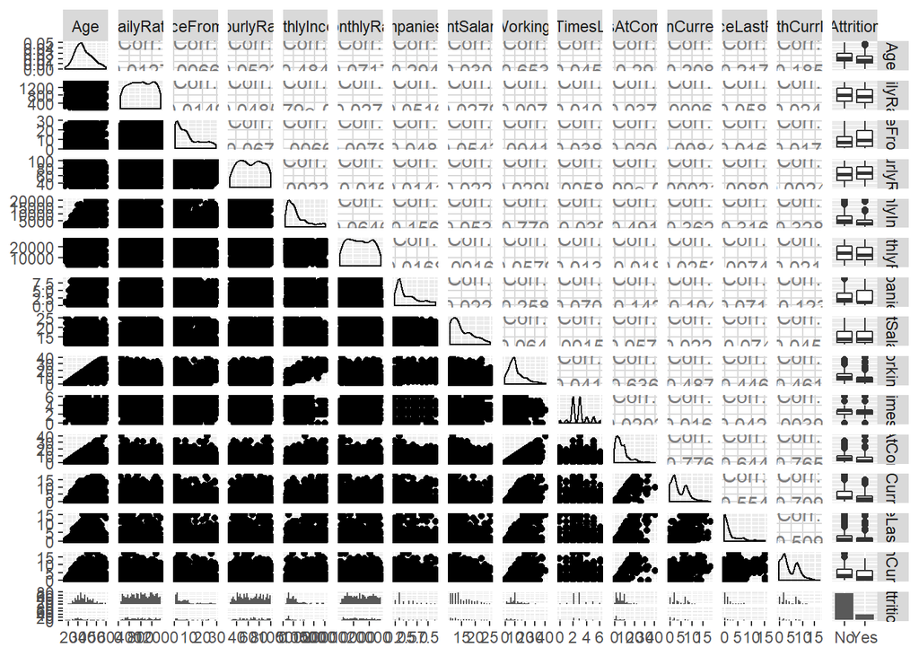

```r
#Change character variables to factors
CaseStudy2CompSet_NO_Salary[,names] <- lapply(CaseStudy2CompSet_NO_Salary[,names] , factor)

ggpairs(CaseStudy2_reorg[,17:31])
```

```r
##MLR model to predict salary


SalaryPrediction_model = lm(MonthlyIncome ~ TotalWorkingYears + JobRole + Department + Gender+ BusinessTravel + DailyRate + JobLevel + PerformanceRating ,data = CaseStudy2_reorg)

summary(SalaryPrediction_model)
```

```
##
## Call:
## lm(formula = MonthlyIncome ~ TotalWorkingYears + JobRole + Department +
##     Gender + BusinessTravel + DailyRate + JobLevel + PerformanceRating,
##     data = CaseStudy2_reorg)
##
## Residuals:
##     Min      1Q  Median      3Q     Max
## -3242.8  -640.1   -91.6   605.2  4130.8
##
## Coefficients:
##                                    Estimate Std. Error t value Pr(>|t|)
## (Intercept)                       2.907e+03  4.775e+02   6.088 1.73e-09
## TotalWorkingYears                 4.633e+01  7.734e+00   5.991 3.08e-09
## JobRoleHuman Resources           -8.866e+02  4.877e+02  -1.818  0.06944
## JobRoleLaboratory Technician     -1.237e+03  1.743e+02  -7.099 2.66e-12
## JobRoleManager                    3.671e+03  2.809e+02  13.071  < 2e-16
## JobRoleManufacturing Director     1.304e+02  1.576e+02   0.827  0.40849
## JobRoleResearch Director          3.510e+03  2.106e+02  16.668  < 2e-16
## JobRoleResearch Scientist        -1.031e+03  1.775e+02  -5.806 9.06e-09
## JobRoleSales Executive            5.554e+02  3.360e+02   1.653  0.09871
## JobRoleSales Representative      -6.725e+02  3.784e+02  -1.777  0.07586
## DepartmentResearch & Development  2.344e+02  4.181e+02   0.561  0.57521
## DepartmentSales                  -3.359e+02  4.274e+02  -0.786  0.43212
## GenderMale                        8.790e+01  6.977e+01   1.260  0.20808
## BusinessTravelTravel_Frequently   2.025e+02  1.318e+02   1.537  0.12476
## BusinessTravelTravel_Rarely       3.466e+02  1.116e+02   3.104  0.00197
## DailyRate                         1.799e-01  8.512e-02   2.113  0.03488
## JobLevel2                         1.707e+03  1.386e+02  12.316  < 2e-16
## JobLevel3                         4.921e+03  1.863e+02  26.421  < 2e-16
## JobLevel4                         8.237e+03  2.812e+02  29.293  < 2e-16
## JobLevel5                         1.089e+04  3.331e+02  32.694  < 2e-16
## PerformanceRating4               -1.213e+02  9.528e+01  -1.274  0.20316
##
## (Intercept)                      ***
## TotalWorkingYears                ***
## JobRoleHuman Resources           .
## JobRoleLaboratory Technician     ***
## JobRoleManager                   ***
## JobRoleManufacturing Director
## JobRoleResearch Director         ***
## JobRoleResearch Scientist        ***
## JobRoleSales Executive           .
## JobRoleSales Representative      .
## DepartmentResearch & Development
## DepartmentSales
## GenderMale
## BusinessTravelTravel_Frequently
## BusinessTravelTravel_Rarely      **
## DailyRate                        *
## JobLevel2                        ***
## JobLevel3                        ***
## JobLevel4                        ***
## JobLevel5                        ***
## PerformanceRating4
## ---
## Signif. codes:  0 '***' 0.001 '**' 0.01 '*' 0.05 '.' 0.1 ' ' 1
##
## Residual standard error: 999 on 849 degrees of freedom
## Multiple R-squared:  0.9539, Adjusted R-squared:  0.9528
## F-statistic: 877.8 on 20 and 849 DF,  p-value: < 2.2e-16
```

```r
confint(SalaryPrediction_model)
```

```
##                                          2.5 %       97.5 %
## (Intercept)                       1.969774e+03  3844.175690
## TotalWorkingYears                 3.115383e+01    61.512561
## JobRoleHuman Resources           -1.843850e+03    70.670375
## JobRoleLaboratory Technician     -1.578941e+03  -894.911572
## JobRoleManager                    3.119982e+03  4222.532785
## JobRoleManufacturing Director    -1.790354e+02   439.739256
## JobRoleResearch Director          3.096300e+03  3922.873825
## JobRoleResearch Scientist        -1.379119e+03  -682.213109
## JobRoleSales Executive           -1.040827e+02  1214.811677
## JobRoleSales Representative      -1.415211e+03    70.134842
## DepartmentResearch & Development -5.861673e+02  1054.901016
## DepartmentSales                  -1.174733e+03   502.948291
## GenderMale                       -4.904708e+01   224.854574
## BusinessTravelTravel_Frequently  -5.615210e+01   461.095028
## BusinessTravelTravel_Rarely       1.274566e+02   565.702078
## DailyRate                         1.280073e-02     0.346937
## JobLevel2                         1.434890e+03  1978.931786
## JobLevel3                         4.555749e+03  5286.955810
## JobLevel4                         7.684796e+03  8788.600674
## JobLevel5                         1.023574e+04 11543.236008
## PerformanceRating4               -3.083533e+02    65.662774
```

```r
#Cross Validation
set.seed(7)
TrainObs = sample(seq(1,dim(CaseStudy2_reorg)[1]),round(.75*dim(CaseStudy2_reorg)[1]),replace = FALSE)
SalaryTrain = CaseStudy2_reorg[TrainObs,]
SalaryTrain
```

```
##        BusinessTravel             Department Education   EducationField
## 298 Travel_Frequently Research & Development         3    Life Sciences
## 467     Travel_Rarely                  Sales         4    Life Sciences
## 415 Travel_Frequently                  Sales         2        Marketing
## 476 Travel_Frequently                  Sales         4        Marketing
## 615     Travel_Rarely                  Sales         2            Other
## 706        Non-Travel                  Sales         2    Life Sciences
## 783     Travel_Rarely        Human Resources         2  Human Resources
## 218 Travel_Frequently Research & Development         3          Medical
## 630     Travel_Rarely Research & Development         3          Medical
## 392     Travel_Rarely                  Sales         3        Marketing
## 835        Non-Travel Research & Development         1          Medical
## 472 Travel_Frequently Research & Development         2    Life Sciences
## 168     Travel_Rarely Research & Development         5          Medical
## 22      Travel_Rarely                  Sales         1        Marketing
```

[output cut: 5862 more lines]

```r
SalaryTest = CaseStudy2_reorg[-TrainObs,]
SalaryTest
```

```
##        BusinessTravel             Department Education   EducationField
## 8       Travel_Rarely                  Sales         4    Life Sciences
## 12         Non-Travel        Human Resources         2    Life Sciences
## 13      Travel_Rarely Research & Development         3            Other
## 15      Travel_Rarely        Human Resources         2    Life Sciences
## 19      Travel_Rarely Research & Development         4          Medical
## 23  Travel_Frequently Research & Development         5          Medical
## 25      Travel_Rarely Research & Development         3    Life Sciences
## 31  Travel_Frequently                  Sales         2          Medical
## 42      Travel_Rarely                  Sales         2 Technical Degree
## 46  Travel_Frequently Research & Development         2          Medical
## 51      Travel_Rarely Research & Development         1    Life Sciences
## 54         Non-Travel Research & Development         2    Life Sciences
## 56      Travel_Rarely Research & Development         4    Life Sciences
## 59         Non-Travel Research & Development         4          Medical
```

[output cut: 1956 more lines]

```r
model1_fit =
SalaryPrediction_model = lm(MonthlyIncome ~ TotalWorkingYears + JobRole + Department + Gender+ BusinessTravel + DailyRate + JobLevel + PerformanceRating ,data = SalaryTrain)
summary(model1_fit)
```

```
##
## Call:
## lm(formula = MonthlyIncome ~ TotalWorkingYears + JobRole + Department +
##     Gender + BusinessTravel + DailyRate + JobLevel + PerformanceRating,
##     data = SalaryTrain)
##
## Residuals:
##     Min      1Q  Median      3Q     Max
## -3327.0  -640.8   -58.5   574.0  3989.8
##
## Coefficients:
##                                    Estimate Std. Error t value Pr(>|t|)
## (Intercept)                       2508.6185   560.9220   4.472 9.18e-06
## TotalWorkingYears                   43.9559     8.7586   5.019 6.78e-07
## JobRoleHuman Resources            -690.2406   568.6585  -1.214  0.22528
## JobRoleLaboratory Technician     -1100.6308   211.8901  -5.194 2.78e-07
## JobRoleManager                    3811.7848   332.0809  11.478  < 2e-16
## JobRoleManufacturing Director      147.7489   189.6050   0.779  0.43613
## JobRoleResearch Director          3535.4086   257.0107  13.756  < 2e-16
## JobRoleResearch Scientist         -915.7924   213.0802  -4.298 2.00e-05
## JobRoleSales Executive             596.7376   396.0050   1.507  0.13234
## JobRoleSales Representative       -638.7687   444.5440  -1.437  0.15124
## DepartmentResearch & Development   402.5007   490.0007   0.821  0.41171
## DepartmentSales                   -157.1946   497.4431  -0.316  0.75210
## GenderMale                         117.6691    82.7057   1.423  0.15530
## BusinessTravelTravel_Frequently    207.6181   158.3999   1.311  0.19043
## BusinessTravelTravel_Rarely        397.3708   134.8792   2.946  0.00334
## DailyRate                            0.2854     0.1004   2.844  0.00461
## JobLevel2                         1833.9818   162.1315  11.312  < 2e-16
## JobLevel3                         4989.8348   216.9193  23.003  < 2e-16
## JobLevel4                         8419.3163   328.2446  25.650  < 2e-16
## JobLevel5                        10951.1874   388.8736  28.161  < 2e-16
## PerformanceRating4                -130.5792   113.3390  -1.152  0.24971
##
## (Intercept)                      ***
## TotalWorkingYears                ***
## JobRoleHuman Resources
## JobRoleLaboratory Technician     ***
## JobRoleManager                   ***
## JobRoleManufacturing Director
## JobRoleResearch Director         ***
## JobRoleResearch Scientist        ***
## JobRoleSales Executive
## JobRoleSales Representative
## DepartmentResearch & Development
## DepartmentSales
## GenderMale
## BusinessTravelTravel_Frequently
## BusinessTravelTravel_Rarely      **
## DailyRate                        **
## JobLevel2                        ***
## JobLevel3                        ***
## JobLevel4                        ***
## JobLevel5                        ***
## PerformanceRating4
## ---
## Signif. codes:  0 '***' 0.001 '**' 0.01 '*' 0.05 '.' 0.1 ' ' 1
##
## Residual standard error: 1020 on 631 degrees of freedom
## Multiple R-squared:  0.9532, Adjusted R-squared:  0.9517
## F-statistic: 642.8 on 20 and 631 DF,  p-value: < 2.2e-16
```

```r
#Prediction Salary(MonthlyIncome) for the CaseStudy2 dataset with NO Salary
CaseStudy2CompSet_NO_Salary$SalaryPreds = predict(SalaryPrediction_model,newdata = CaseStudy2CompSet_NO_Salary)


view(CaseStudy2CompSet_NO_Salary)

#Create dataframe with ID and Salary Predictions only
ID_SalaryPreds_Dataframe <- CaseStudy2CompSet_NO_Salary[,c("ID","SalaryPreds")]
ID_SalaryPreds_Dataframe
```

```
## # A tibble: 300 x 2
##       ID SalaryPreds
##    <dbl>       <dbl>
##  1   871       5690.
##  2   872       2744.
##  3   873      13014.
##  4   874       2403.
##  5   875       3005.
##  6   876       5152.
##  7   877       5465.
##  8   878       2047.
##  9   879       3004.
## 10   880      13551.
## # ... with 290 more rows
```

```r
#Save data to CSV file
write.table(ID_SalaryPreds_Dataframe,"Case2PredictionsDebouseSalary.csv",sep = ",",row.names = FALSE)
```